# 1: Abstract

Breast cancer is a serious global public health concern, and precise prediction of its occurrence is critical for early detection and effective treatment. This study investigates the use of Support Vector Machines (SVM) to detect breast cancer and compares its performance to other machine learning (ML) algorithms.

The dataset for this study includes several factors relating to patient characteristics, tumour attributes, and medical history. Preprocessing procedures are used to clean and normalise the data, making it suitable for use in predictive modelling. The dataset is then split into training and testing datasets.

Support Vector Machines, which are well-known for their ability to handle high-dimensional data, are being used to predict breast cancer. Cross-validation is used to fine-tune the hyperparameters of the SVM model to improve its performance.

## 2: Introduction

Breast cancer remains a pervasive and serious ailment, demanding advanced techniques for early detection and prognosis. Machine learning (ML) algorithms offer promising avenues for predictive modelling in medical domains, potentially improving diagnostic accuracy and patient outcomes. This study focuses on applying Support Vector Machines (SVM) to predict breast cancer, assessing its effectiveness and comparing it with other notable ML algorithms.

Accurate breast cancer prediction is crucial for timely interventions and tailored treatments, leading to better survival rates and reduced morbidity Siegel et al. (2020). ML algorithms, adept at handling complex datasets, hold promise for advancing medical diagnostics by capturing intricate patterns.

Support Vector Machines, known for handling high-dimensional data and non-linear relationships, provide a robust framework for predictive modelling as explained by Cortes & Vapnik (1995). By defining an optimal hyperplane to separate data points into distinct classes, SVMs discern patterns that conventional statistical methods may miss. However, the efficacy of SVM in breast cancer prediction requires exploration.

This report conducts a comparative study, evaluating SVM against ML algorithms like random forests, linear discriminant analysis (LDA), and logistic regression decision tree and gaussian naive bayes. Our goal is to determine the most accurate prediction algorithm for breast cancer by leveraging a comprehensive dataset containing patients medical history.

The study outcomes could enhance healthcare tools, enabling informed decision-making and improving patient care and treatment outcomes in breast cancer management.

## 3: Methodology

**Data Processing and Visualization**:

- The dataset will be preprocessed to handle missing values, outliers, and ensure data quality.
- Exploratory data analysis (EDA) techniques will be employed to gain insights into the distribution of features, identify patterns, and understand relationships between variables.

**Feature Engineering and Dimensionality Reduction**:

- Relevant features will be selected or engineered from the dataset to improve model performance and interpretability.
- Techniques such as dimensionality reduction, using Principal Component Analysis (PCA), will be applied to reduce the number of features while preserving important information.

**Clustering Analysis**:

- Clustering algorithms, such as K-means clustering, will be applied to identify natural groupings or clusters within the dataset.
- Clustering results will be visualized to explore inherent structures and potential subgroups within the data.

**Building Support Vector Machine (SVM) Model**:

- A SVM model will be trained on the preprocessed dataset to predict breast cancer outcomes.
- Hyperparameter tuning techniques, such as grid search, will be utilized to optimize the SVM model's performance.

**Comparative Analysis**:

- The SVM model's performance will be evaluated and compared with other machine learning algorithms, including random forests, Linear Discriminant Analysis (LDA), and logistic regression, gaussianNB, decision tree.
- Performance metrics such as accuracy, precision, recall, and F1-score will be calculated for each model to assess their predictive capabilities.

**Conclusion**:

- The study outcomes will be summarized, highlighting the effectiveness of SVM and other algorithms in predicting breast cancer.
- Insights gained from dimensionality reduction and clustering analysis will be discussed, along with implications for clinical practice and future research directions.

## 4: Analysis

### 4.1 Overview

Fine Needle Aspiration (FNA) is a minimally invasive procedure used for extracting cell samples from breast abnormalities. According to the blog post by Cancer Research UK (2023) This involves the insertion of a thin, hollow needle into the suspicious area, guided by ultrasound or mammography for precise targeting. Local anesthesia may be administered to minimize discomfort during the procedure, making FNA an efficient and well-tolerated method for obtaining diagnostic cell samples from breast tissues. which is then classified into:

- 1 = Malignant (Cancerous): Indicates the presence of cancer.
- 0 = Benign (Not Cancerous): Indicates the absence of cancer.

### 4.2 Objective

Because the labels used in the data are discrete, the prediction can be divided into two categories. In machine learning, this is a classification problem.

> *The goal is to categorise breast cancer as benign or malignant and to forecast the recurrence and non-recurrence of malignant instances after a given period. We applied machine learning classification algorithms to create a function capable of predicting the discrete class of fresh data.*

### 4.3 Identify data sources and initial data processing

- The first two columns in the dataset store the unique ID numbers of the samples and the corresponding diagnosis (M = malignant, B = benign), respectively.
- The columns 3-32 contain 30 real-value features that have been computed from digitized images of the cell nuclei, which can be used to build a model to predict whether a tumor is benign or malignant.

#### Loading libraries

```python
# load libraries
import numpy as np         # linear algebra
import pandas as pd      # data processing, CSV file I/O (e.g. pd.read_csv)
from sklearn.preprocessing import LabelEncoder
```

#### Load Dataset

First, load the supplied CSV file using additional options in the Pandas **`read_csv`** function.

```python
# Read the file "MS4S16_Dataset" and print the contents.
df = pd.read_csv('Data/MS4S16_Dataset.csv', index_col=False)
```

#### Inspecting the data

The first step is to visually inspect the data set using **`data.head()`** whcih returns the first 5 rows from the DataFrame object df (excluding the header row) or **`df.tail()`** to return the five rows of the data frame.

```python
df.head()
```

|  | id | diagnosis | radius_mean | texture_mean | perimeter_mean | area_mean | smoothness_mean | compactness_mean | concavity_mean | concave points_mean | ... | radius_worst | texture_worst | perimeter_worst | area_worst | smoothness_worst | compactness_worst | concavity_worst | concave points_worst | symmetry_worst | fractal_dimension_worst |
| --- | --- | --- | --- | --- | --- | --- | --- | --- | --- | --- | --- | --- | --- | --- | --- | --- | --- | --- | --- | --- | --- |
| 0 | 842302.0 | M | 17.99 | 10.38 | 122.80 | 1001.0 | 0.11840 | 0.27760 | 0.3001 | 0.14710 | ... | 25.38 | 17.33 | 184.60 | 2019.0 | 0.1622 | 0.6656 | 0.7119 | 0.2654 | 0.4601 | 0.11890 |
| 1 | 842517.0 | M | 20.57 | 17.77 | 132.90 | 1326.0 | 0.08474 | 0.07864 | 0.0869 | 0.07017 | ... | 24.99 | 23.41 | 158.80 | 1956.0 | 0.1238 | 0.1866 | 0.2416 | 0.1860 | 0.2750 | 0.08902 |
| 2 | 84300903.0 | M | 19.69 | 21.25 | 130.00 | 1203.0 | 0.10960 | 0.15990 | 0.1974 | 0.12790 | ... | 23.57 | 25.53 | 152.50 | 1709.0 | 0.1444 | 0.4245 | 0.4504 | 0.2430 | 0.3613 | 0.08758 |
| 3 | 84348301.0 | M | 11.42 | 20.38 | 77.58 | 386.1 | 0.14250 | 0.28390 | 0.2414 | 0.10520 | ... | 14.91 | 26.50 | 98.87 | 567.7 | 0.2098 | 0.8663 | 0.6869 | 0.2575 | 0.6638 | 0.17300 |
| 4 | 84358402.0 | M | 20.29 | 14.34 | 135.10 | 1297.0 | 0.10030 | 0.13280 | 0.1980 | 0.10430 | ... | 22.54 | 16.67 | 152.20 | 1575.0 | 0.1374 | 0.2050 | 0.4000 | 0.1625 | 0.2364 | 0.07678 |

5 rows × 32 columns

We can check the number of cases, and the number of fields, using the shape method.

```python
df.shape
```

```
(571, 32)
```

```python
# Review data types with "info()".
df.info()
```

```
<class 'pandas.core.frame.DataFrame'>
RangeIndex: 571 entries, 0 to 570
Data columns (total 32 columns):
 #   Column                   Non-Null Count  Dtype
---  ------                   --------------  -----
 0   id                       568 non-null    float64
 1   diagnosis                568 non-null    object
 2   radius_mean              566 non-null    float64
 3   texture_mean             565 non-null    float64
 4   perimeter_mean           567 non-null    float64
 5   area_mean                566 non-null    float64
 6   smoothness_mean          568 non-null    float64
 7   compactness_mean         567 non-null    float64
 8   concavity_mean           567 non-null    float64
 9   concave points_mean      563 non-null    float64
```

[output cut: 24 more lines]

```python
# Check for missing variables
df.isnull().any()
```

```
id                         True
diagnosis                  True
radius_mean                True
texture_mean               True
perimeter_mean             True
area_mean                  True
smoothness_mean            True
compactness_mean           True
concavity_mean             True
concave points_mean        True
symmetry_mean              True
fractal_dimension_mean     True
radius_se                  True
texture_se                 True
perimeter_se               True
area_se                    True
smoothness_se              True
compactness_se             True
concavity_se               True
concave points_se          True
symmetry_se                True
fractal_dimension_se       True
radius_worst               True
texture_worst              True
perimeter_worst            True
area_worst                 True
smoothness_worst           True
compactness_worst          True
concavity_worst            True
concave points_worst       True
symmetry_worst             True
fractal_dimension_worst    True
dtype: bool
```

```python
df.isnull().sum()
```

```
id                          3
diagnosis                   3
radius_mean                 5
texture_mean                6
perimeter_mean              4
area_mean                   5
smoothness_mean             3
compactness_mean            4
concavity_mean              4
concave points_mean         8
symmetry_mean               3
fractal_dimension_mean      4
radius_se                   6
texture_se                  8
perimeter_se                3
area_se                     6
smoothness_se               6
compactness_se              7
concavity_se                8
concave points_se           9
symmetry_se                 8
fractal_dimension_se        7
radius_worst               13
texture_worst              21
perimeter_worst             6
area_worst                  4
smoothness_worst            9
compactness_worst           4
concavity_worst             3
concave points_worst        6
symmetry_worst              4
fractal_dimension_worst    13
dtype: int64
```

#### Handling missing values

We noticed that there are missing values in all the columns, let's fix this. First we will drop roles that are completely empty.

secondly,separate the numerial columns from the categorical ones, we have to handle them separtely. We will use the mean value to replace the remaing missing values in the `numerical columns` and the most occuring values for the `categorical column` using the **`SimpleImputer`** library

```python
# To drop rows that are completely empty (i.e., rows with NaN values accross all columns)
df.dropna(axis=0, how='all', inplace=True)
```

```python
df.isnull().sum()
```

```
id                          0
diagnosis                   0
radius_mean                 2
texture_mean                3
perimeter_mean              1
area_mean                   2
smoothness_mean             0
compactness_mean            1
concavity_mean              1
concave points_mean         5
symmetry_mean               0
fractal_dimension_mean      1
radius_se                   3
texture_se                  5
perimeter_se                0
area_se                     3
smoothness_se               3
compactness_se              4
concavity_se                5
concave points_se           6
symmetry_se                 5
fractal_dimension_se        4
radius_worst               10
texture_worst              18
perimeter_worst             3
area_worst                  1
smoothness_worst            6
compactness_worst           1
concavity_worst             0
concave points_worst        3
symmetry_worst              1
fractal_dimension_worst    10
dtype: int64
```

```python
# Separate numerical and categorical columns
numerical_features = df.select_dtypes(include=[np.number]).columns
categorical_features = df.select_dtypes(include=[object]).columns
```

```python
from sklearn.impute import SimpleImputer

# Impute missing values for numerical columns with mean
numerical_imputer = SimpleImputer(strategy='mean')
df[numerical_features] = numerical_imputer.fit_transform(
    df[numerical_features])

# Impute missing values for categorical columns with most frequent value
categorical_imputer = SimpleImputer(strategy='most_frequent')
df[categorical_features] = categorical_imputer.fit_transform(
    df[categorical_features])
```

```python
# checking to comfirm we successfully handled the missing values.
# it should rreturn false now for all
df.isnull().any()
```

```
id                         False
diagnosis                  False
radius_mean                False
texture_mean               False
perimeter_mean             False
area_mean                  False
smoothness_mean            False
compactness_mean           False
concavity_mean             False
concave points_mean        False
symmetry_mean              False
fractal_dimension_mean     False
radius_se                  False
texture_se                 False
perimeter_se               False
area_se                    False
smoothness_se              False
compactness_se             False
concavity_se               False
concave points_se          False
symmetry_se                False
fractal_dimension_se       False
radius_worst               False
texture_worst              False
perimeter_worst            False
area_worst                 False
smoothness_worst           False
compactness_worst          False
concavity_worst            False
concave points_worst       False
symmetry_worst             False
fractal_dimension_worst    False
dtype: bool
```

```python
df.diagnosis.unique()
```

```
array(['M', 'B'], dtype=object)
```

Based on the above results, the diagnosis is classified as a categorical variable since it has a fixed range of possible values (i.e., Benign or Malignant). Machine learning algorithms prefer numbers over strings as inputs, thus we need a method to convert them. we will do this later in the analysis.

```python
# Save the a version of dataframe with "id" for future analyis
df.to_csv('Data/MS4S16_Dataset_id.csv')
```

```python
# Id column is redundant and not useful, we will drop it
df.drop('id', axis=1, inplace=True)
# df.drop('Unnamed: 0', axis=1, inplace=True)
df.head(3)
```

|  | diagnosis | radius_mean | texture_mean | perimeter_mean | area_mean | smoothness_mean | compactness_mean | concavity_mean | concave points_mean | symmetry_mean | ... | radius_worst | texture_worst | perimeter_worst | area_worst | smoothness_worst | compactness_worst | concavity_worst | concave points_worst | symmetry_worst | fractal_dimension_worst |
| --- | --- | --- | --- | --- | --- | --- | --- | --- | --- | --- | --- | --- | --- | --- | --- | --- | --- | --- | --- | --- | --- |
| 0 | M | 17.99 | 10.38 | 122.8 | 1001.0 | 0.11840 | 0.27760 | 0.3001 | 0.14710 | 0.2419 | ... | 25.38 | 17.33 | 184.6 | 2019.0 | 0.1622 | 0.6656 | 0.7119 | 0.2654 | 0.4601 | 0.11890 |
| 1 | M | 20.57 | 17.77 | 132.9 | 1326.0 | 0.08474 | 0.07864 | 0.0869 | 0.07017 | 0.1812 | ... | 24.99 | 23.41 | 158.8 | 1956.0 | 0.1238 | 0.1866 | 0.2416 | 0.1860 | 0.2750 | 0.08902 |
| 2 | M | 19.69 | 21.25 | 130.0 | 1203.0 | 0.10960 | 0.15990 | 0.1974 | 0.12790 | 0.2069 | ... | 23.57 | 25.53 | 152.5 | 1709.0 | 0.1444 | 0.4245 | 0.4504 | 0.2430 | 0.3613 | 0.08758 |

3 rows × 31 columns

```python
# Save the cleaner version of dataframe without id for future analyis
df.to_csv('Data/MS4S16_Dataset_clean.csv')
```

> Now that we have a solid intuitive understanding of the data, the next step is to look more closely at the properties and data values. let's go further into the data.

### 4.4: Exploratory Data Analysis

Exploratory data analysis (EDA) is a very important step to understand the nature of the data without making assumptions. The results of data exploration can be extremely useful in grasping the structure of the data, the distribution of the values, and the presence of extreme values and interrelationships within the data set.

There are two approached used to examine the data:

1. *Descriptive statistics*
2. *Visualization*

#### Descriptive statistics

```python
%matplotlib inline
import matplotlib.pyplot as plt

#Load libraries for data processing
import pandas as pd #data processing, CSV file I/O (e.g. pd.read_csv)
import numpy as np
from scipy.stats import norm
import seaborn as sns # data visualization


plt.rcParams['figure.figsize'] = (15,8)
plt.rcParams['axes.titlesize'] = 'large'
```

```python
# using clean data with "id"
df = pd.read_csv('Data/MS4S16_Dataset_id.csv', index_col=False)
df.drop('Unnamed: 0', axis=1, inplace=True)
df.head(3)
```

|  | id | diagnosis | radius_mean | texture_mean | perimeter_mean | area_mean | smoothness_mean | compactness_mean | concavity_mean | concave points_mean | ... | radius_worst | texture_worst | perimeter_worst | area_worst | smoothness_worst | compactness_worst | concavity_worst | concave points_worst | symmetry_worst | fractal_dimension_worst |
| --- | --- | --- | --- | --- | --- | --- | --- | --- | --- | --- | --- | --- | --- | --- | --- | --- | --- | --- | --- | --- | --- |
| 0 | 842302.0 | M | 17.99 | 10.38 | 122.8 | 1001.0 | 0.11840 | 0.27760 | 0.3001 | 0.14710 | ... | 25.38 | 17.33 | 184.6 | 2019.0 | 0.1622 | 0.6656 | 0.7119 | 0.2654 | 0.4601 | 0.11890 |
| 1 | 842517.0 | M | 20.57 | 17.77 | 132.9 | 1326.0 | 0.08474 | 0.07864 | 0.0869 | 0.07017 | ... | 24.99 | 23.41 | 158.8 | 1956.0 | 0.1238 | 0.1866 | 0.2416 | 0.1860 | 0.2750 | 0.08902 |
| 2 | 84300903.0 | M | 19.69 | 21.25 | 130.0 | 1203.0 | 0.10960 | 0.15990 | 0.1974 | 0.12790 | ... | 23.57 | 25.53 | 152.5 | 1709.0 | 0.1444 | 0.4245 | 0.4504 | 0.2430 | 0.3613 | 0.08758 |

3 rows × 32 columns

```python
# basic descriptive statistics
df.describe()
```

|  | id | radius_mean | texture_mean | perimeter_mean | area_mean | smoothness_mean | compactness_mean | concavity_mean | concave points_mean | symmetry_mean | ... | radius_worst | texture_worst | perimeter_worst | area_worst | smoothness_worst | compactness_worst | concavity_worst | concave points_worst | symmetry_worst | fractal_dimension_worst |
| --- | --- | --- | --- | --- | --- | --- | --- | --- | --- | --- | --- | --- | --- | --- | --- | --- | --- | --- | --- | --- | --- |
| count | 5.680000e+02 | 568.000000 | 568.000000 | 568.000000 | 568.000000 | 568.000000 | 568.000000 | 568.000000 | 568.000000 | 568.000000 | ... | 568.000000 | 568.000000 | 568.000000 | 568.000000 | 568.000000 | 568.000000 | 568.000000 | 568.000000 | 568.000000 | 568.000000 |
| mean | 3.011402e+07 | 14.103267 | -241.973664 | 91.949048 | 654.942403 | 0.096312 | 0.104333 | 0.088712 | -3.500369 | 0.187402 | ... | 16.269794 | 25.735691 | 110.948035 | 897.936508 | 0.132469 | 0.254412 | 0.272125 | 0.114470 | 0.290327 | 0.084020 |
| std | 1.250894e+08 | 3.511215 | 444.037478 | 24.336540 | 351.933558 | 0.014178 | 0.052832 | 0.079669 | 59.229413 | 0.115008 | ... | 4.799478 | 6.025789 | 59.088749 | 687.623877 | 0.022744 | 0.157443 | 0.208867 | 0.065680 | 0.061853 | 0.018010 |
| min | 8.670000e+03 | 6.981000 | -999.000000 | 43.790000 | 143.500000 | 0.052630 | 0.019380 | 0.000000 | -999.000000 | 0.000700 | ... | 7.930000 | 12.020000 | 50.410000 | 185.200000 | 0.071170 | 0.027290 | 0.000000 | 0.000000 | 0.156500 | 0.055040 |
| 25% | 8.690778e+05 | 11.697500 | -999.000000 | 75.200000 | 420.300000 | 0.086290 | 0.064815 | 0.029540 | 0.019603 | 0.161900 | ... | 13.050000 | 21.397500 | 84.302500 | 515.675000 | 0.117075 | 0.147575 | 0.114475 | 0.064967 | 0.250475 | 0.071733 |
| 50% | 9.060010e+05 | 13.355000 | 16.970000 | 86.290000 | 551.400000 | 0.095895 | 0.093125 | 0.061545 | 0.032770 | 0.179200 | ... | 15.010000 | 25.580000 | 97.930000 | 687.100000 | 0.131550 | 0.214850 | 0.227450 | 0.100550 | 0.282600 | 0.080140 |
| 75% | 8.812852e+06 | 15.780000 | 21.002500 | 104.150000 | 784.150000 | 0.105325 | 0.130400 | 0.129650 | 0.071330 | 0.195700 | ... | 18.550000 | 29.415000 | 126.750000 | 1089.750000 | 0.146000 | 0.339300 | 0.383500 | 0.161300 | 0.318475 | 0.092037 |
| max | 9.113205e+08 | 28.110000 | 39.280000 | 188.500000 | 2501.000000 | 0.163400 | 0.345400 | 0.426800 | 0.201200 | 2.100000 | ... | 36.040000 | 49.540000 | 910.000000 | 10056.000000 | 0.222600 | 1.058000 | 1.252000 | 0.291000 | 0.663800 | 0.207500 |

8 rows × 31 columns

```python
# Filter out only numeric columns
numeric_columns = df.select_dtypes(include=['number'])
```

```python
numeric_columns.skew()
```

```
id                          6.480339
radius_mean                 0.930175
texture_mean               -1.120007
perimeter_mean              0.977768
area_mean                   1.643203
smoothness_mean             0.406965
compactness_mean            1.188868
concavity_mean              1.402965
concave points_mean       -16.806773
symmetry_mean              15.293945
fractal_dimension_mean     -8.268612
radius_se                   3.087723
texture_se                  1.646811
perimeter_se                3.429533
area_se                     5.415647
smoothness_se               2.352905
compactness_se              1.927998
concavity_se                5.110757
concave points_se           1.434727
symmetry_se                 2.187321
fractal_dimension_se       23.681249
radius_worst                1.111793
texture_worst               0.523202
perimeter_worst             8.030332
area_worst                  5.186129
smoothness_worst            0.411384
compactness_worst           1.469556
concavity_worst             1.147034
concave points_worst        0.492108
symmetry_worst              1.428565
fractal_dimension_worst     1.672480
dtype: float64
```

> The skew result show a positive (right) or negative (left) skew. Values closer to zero show less skew.

```python
df.diagnosis.unique()
```

```
array(['M', 'B'], dtype=object)
```

```python
# Group by diagnosis and review the output.
diag_gr = df.groupby('diagnosis', axis=0)
pd.DataFrame(diag_gr.size(), columns=['No of observations'])
```

| diagnosis | No of observations |
| --- | --- |
| B | 356 |
| M | 212 |

#### **Observation**

> *356 observations indicating the absence of cancer cells and 212 show presence of cancer cell*

Lets confirm this, by ploting the histogram. But we will need to encode the diagnosis categorical data into numeric first, where

- Malignant = 1 (indicates prescence of cancer cells)
- Benign = 0 (indicates abscence)

```
 [Text(0, 0, 'B'), Text(1, 0, 'M')])
```

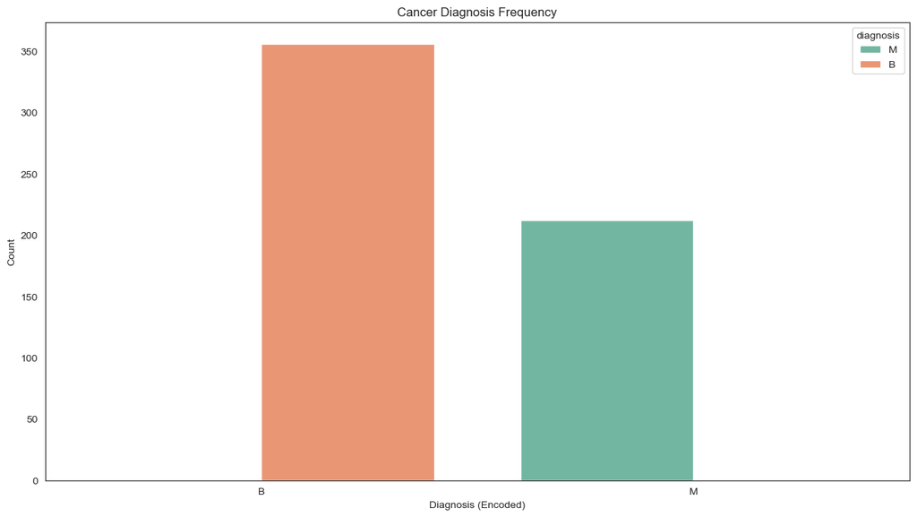

```python
# Convert 'diagnosis' which is a categorical variable to numbers
label_encoder = LabelEncoder()
df['diagnosis_encoded'] = label_encoder.fit_transform(df['diagnosis'])

sns.set_style("white")
sns.set_context({"figure.figsize": (15, 8)})

# Use the encoded column for countplot
sns.countplot(x='diagnosis_encoded', data=df, hue='diagnosis', palette="Set2")

# Add labels and title
plt.title('Cancer Diagnosis Frequency')
plt.xlabel('Diagnosis (Encoded)')
plt.ylabel('Count')

plt.xticks([0, 1], label_encoder.classes_)
```

```python
print(df['diagnosis'].value_counts())
print(label_encoder.classes_)
```

```
diagnosis
B    356
M    212
Name: count, dtype: int64
['B' 'M']
```

#### Data Visualizations

One of the main goals of visualizing the data here is to observe which features are most helpful in predicting malignant or benign cancer. The other is to see general trends that may aid us in model selection and hyper parameter selection.

#### Separate columns into smaller dataframes to perform visualization

```python
# Break up columns into groups, according to their suffix designation
# (_mean, _se,and __worst) to perform visualisation plots off.
# Join the 'ID' and 'Diagnosis' back on

df_id_diag = df.loc[:, ["id", "diagnosis"]]
df_diag = df.loc[:, ["diagnosis"]]

# For a merge + slice:
df_mean = df.iloc[:, 1:12]
df_se = df.iloc[:, 12:22]
df_worst = df.iloc[:, 22:]

print(df_id_diag.columns)
# print(data_mean.columns)
# print(data_se.columns)
# print(data_worst.columns)
```

```
Index(['id', 'diagnosis'], dtype='object')
```

#### Histogram the `_mean` suffix designition

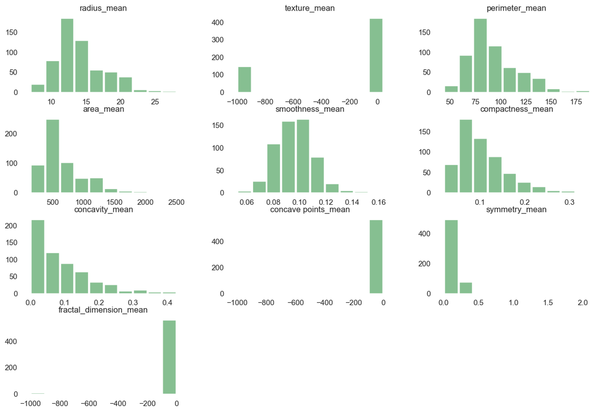

```python
# Plot histograms of _mean variables

# Set up a Seaborn style
sns.set(style="whitegrid", palette="pastel")

# Create a histogram with Seaborn
hist_mean = df_mean.hist(bins=10, figsize=(
    15, 10), grid=False, color='#86bf91', zorder=2, rwidth=0.9)

# Remove ticks
plt.tick_params(axis='both', which='both', length=0)

# Despine
sns.despine(left=True, bottom=True)

# Show the plot
plt.show()
```

#### Histogram for the `_se` suffix designition

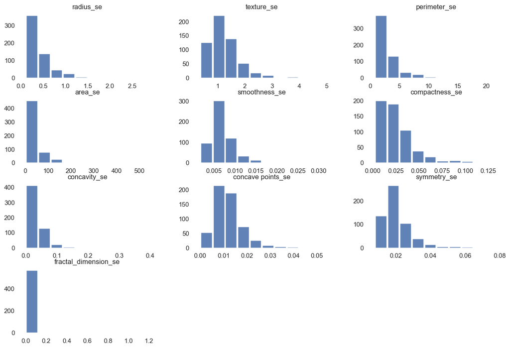

```python
# Plot histograms of _se variables

# Set up a Seaborn style
sns.set(style="whitegrid", palette="pastel")

# Create a histogram with Seaborn
hist_mean = df_se.hist(bins=10, figsize=(15, 10), grid=False,
                       color='#6082B6', zorder=2, rwidth=0.9)

# Remove ticks
plt.tick_params(axis='both', which='both', length=0)

# Despine
sns.despine(left=True, bottom=True)

# Show the plot
plt.show()
```

#### Histogram `_worst` suffix designition

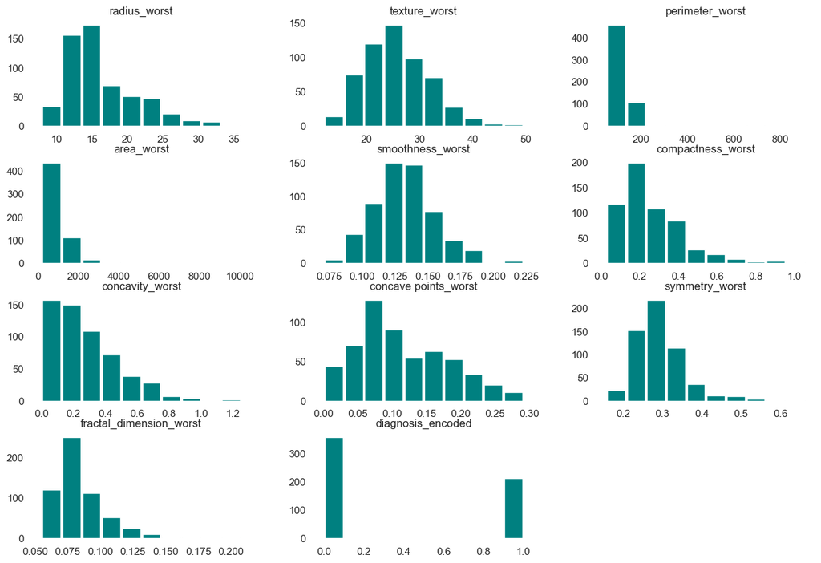

```python
# Plot histograms of _worst variables

# Set up a Seaborn style
sns.set(style="whitegrid", palette="pastel")

# Create a histogram with Seaborn
hist_mean = df_worst.hist(bins=10, figsize=(
    15, 10), grid=False, color='#008080', zorder=2, rwidth=0.9)

# Remove ticks
plt.tick_params(axis='both', which='both', length=0)

# Despine
sns.despine(left=True, bottom=True)

# Show the plot
plt.show()
```

### **Observation**

> We can see that perhaps the attributes **`concavity`**, and **`concave_point`** may have an exponential distribution ( ). We can also see that the texture, smooth and symmetry attributes may have a Gaussian or nearly Gaussian distribution. This is interesting because many machine learning techniques assume a Gaussian univariate distribution on the input variables.

#### Visualize distribution of data via density plots

#### Density plots `_mean` suffix designition

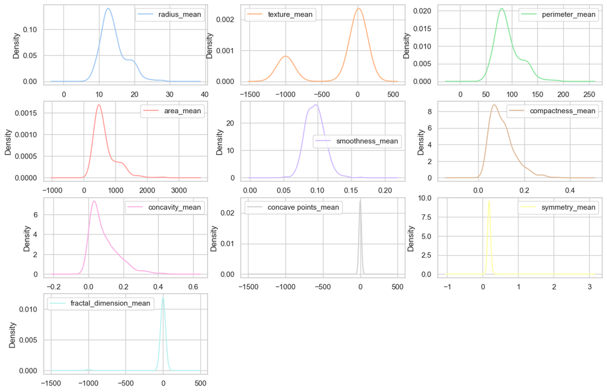

```python
# Density Plots
plt = df_mean.plot(kind='density', subplots=True, layout=(4, 3), sharex=False,
                   sharey=False, fontsize=11, figsize=(15, 10))
```

#### Density plots `_se` suffix designition

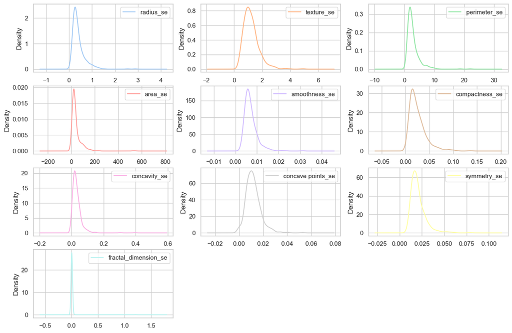

```python
# Density Plots
plt = df_se.plot(kind='density', subplots=True, layout=(4, 3), sharex=False,
                 sharey=False, fontsize=11, figsize=(15, 10))
```

#### Density plot `_worst` suffix designition

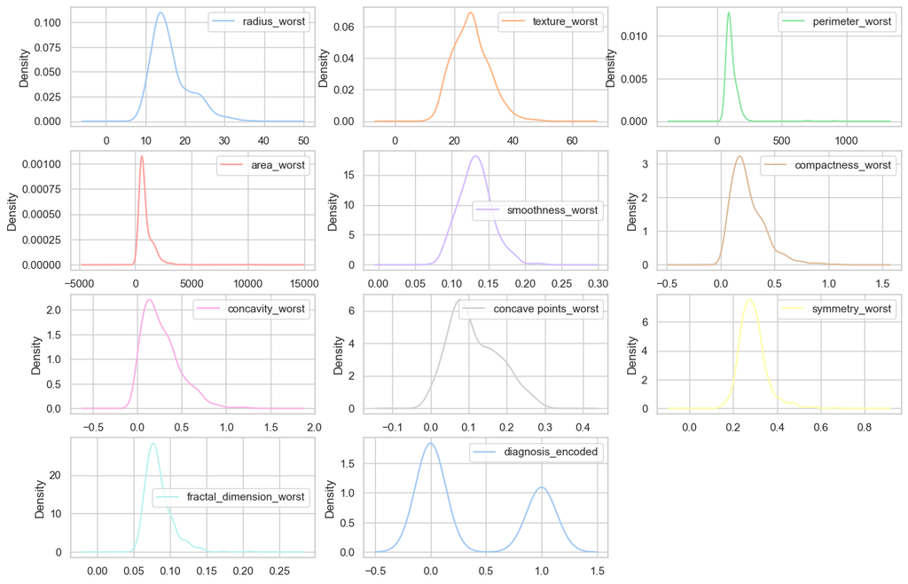

```python
# Density Plots
plt = df_worst.plot(kind='kde', subplots=True, layout=(4, 3), sharex=False, sharey=False,
                    fontsize=11, figsize=(15, 10))
```

### Observation

> We can see that perhaps the attributes perimeter,radius, area, concavity, compactness may have an exponential distribution( ). We can also see that perhaps the texture and smooth and symmetry attributes may have a Gaussian or nearly Gaussian distribution. This is interesting because many machine learning techniques assume a Gaussian univariate distribution on the input variables.

#### Visualise distribution of data via box plots

#### Box plot `_mean` suffix designition

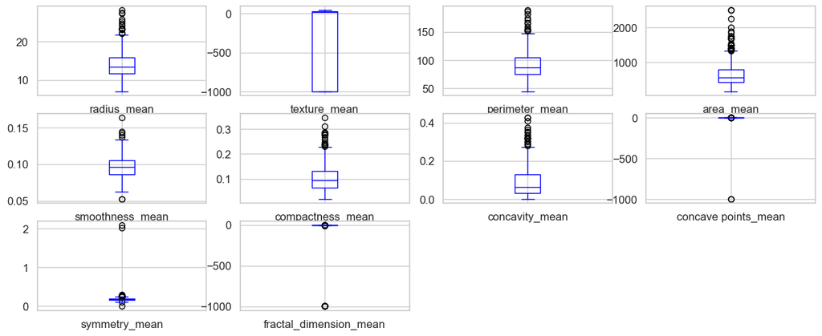

```python
# box and whisker plots
plt = df_mean.plot(kind='box', subplots=True, layout=(4, 4), sharex=False, sharey=False,
                   fontsize=12, color='blue')  # You can choose any color you prefer
```

#### Box plot `_se` suffix designition

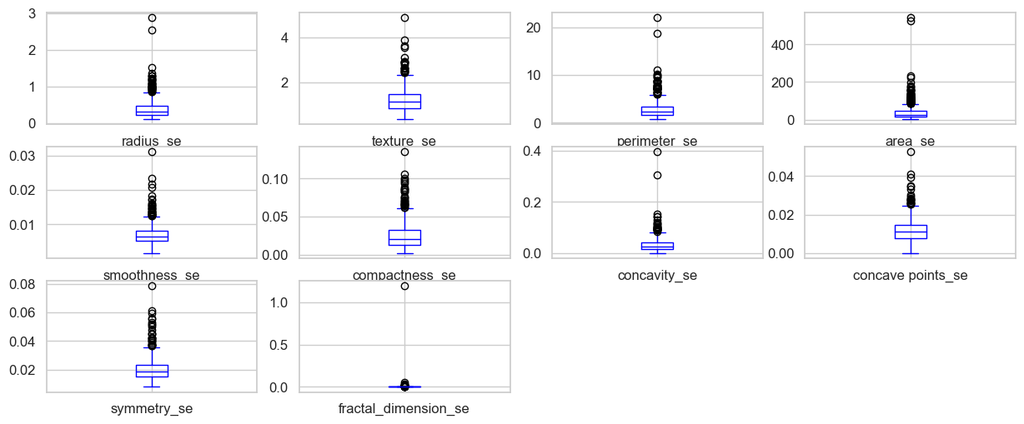

```python
# box and whisker plots
plt = df_se.plot(kind='box', subplots=True, layout=(4, 4), sharex=False, sharey=False,
                 fontsize=12, color='blue')  # You can choose any color you prefer
```

#### Box plot `_worst` suffix designition

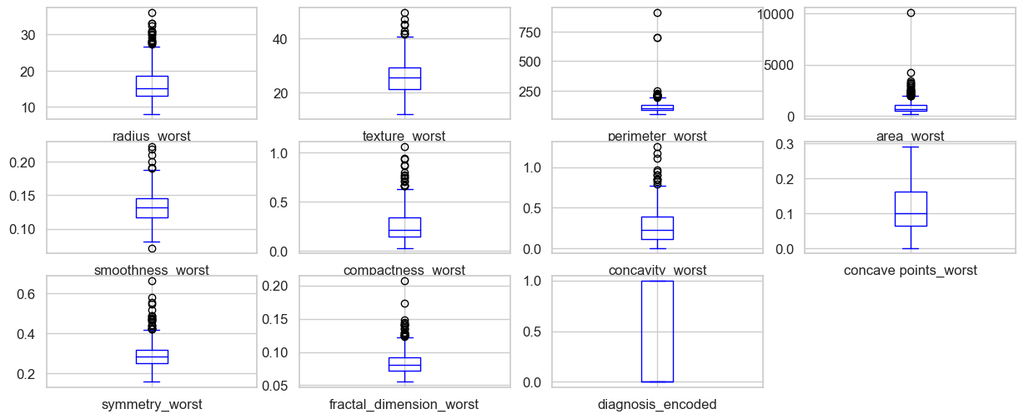

```python
# box and whisker plots
plt = df_worst.plot(kind='box', subplots=True, layout=(4, 4), sharex=False, sharey=False,
                    fontsize=12, color='blue')  # You can choose any color you prefer
```

#### Observation

> We can see that the attributes perimeter,radius, area, concavity,compactness may have an exponential distribution( ). We can also see that the texture, smooth and symmetry attributes may have a Gaussian or nearly Gaussian distribution. This is interesting because many machine learning techniques assume a Gaussian univariate distribution on the input variables.

#### Correlation matrix

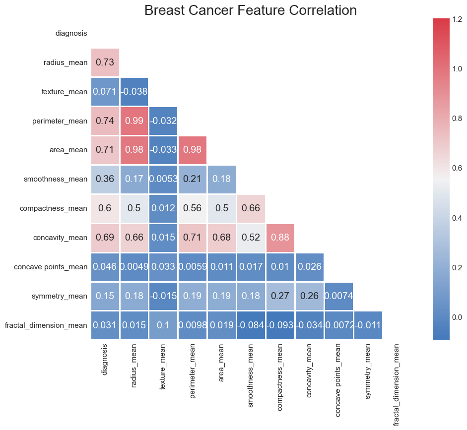

```python
# plot correlation matrix
import pandas as pd
import numpy as np
import seaborn as sns
from matplotlib import pyplot as plt

plt.style.use('fivethirtyeight')
sns.set_style("white")

df = pd.read_csv('Data/MS4S16_Dataset_clean.csv', index_col=False)

df_mean['diagnosis'] = df_mean['diagnosis'].map({'M': 1, 'B': 0})

# Compute the correlation matrix for _mean suffix

np.random.seed(42)

corr = df_mean.corr()

# Generate a mask for the upper triangle
mask = np.zeros_like(corr, dtype=bool)
mask[np.triu_indices_from(mask)] = True

# Set up the matplotlib figure
fig, ax = plt.subplots(figsize=(10, 8))
plt.title('Breast Cancer Feature Correlation')

# Generate a custom diverging colormap
cmap = sns.diverging_palette(250, 10, as_cmap=True)

# Draw the heatmap with the mask and correct aspect ratio
sns.heatmap(corr, vmax=1.2, square=True, cmap=cmap, mask=mask,
            ax=ax, annot=True, fmt='.2g', linewidths=2)

plt.show()
```

#### Observation:

> We can see strong positive relationship exists with mean values paramaters between **1** to **0.74**.
> - The mean area of the tissue nucleus has a strong positive correlation with mean values of radius and parameter;
> - Some paramters are moderately positive corrlated (r between 0.5-0.74). Concavity and area, concavity and perimeter etc
> - Likewise, we see some weak correlation between fractal_dimension with radius, texture, parameter mean values.

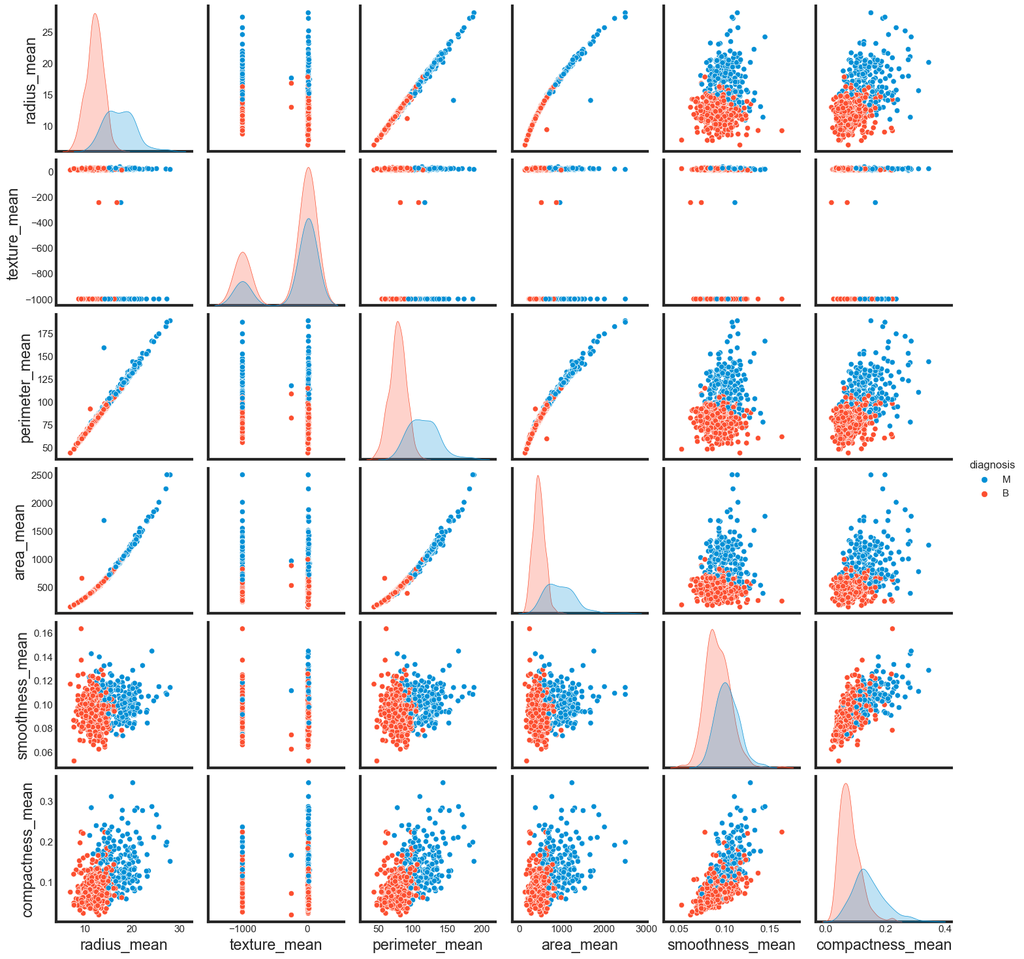

```python
# Create pair plots for column 1 to 8
sns.pairplot(df.iloc[:, 1:8], hue='diagnosis')
```

### 4.5 Data Preprocessing

- Converting categorical data into numerical values.
- Addressing missing values.
- Normalizing features to prevent small-scale features from dominating the model fitting process.

```python
%matplotlib inline
import matplotlib.pyplot as plt
from scipy.stats import norm

# visualization
import seaborn as sns
plt.style.use('fivethirtyeight')
sns.set_style("white")


plt.rcParams['figure.figsize'] = (8,4)
#plt.rcParams['axes.titlesize'] = 'large'

df = pd.read_csv('Data/MS4S16_Dataset_clean.csv', index_col=False)
df.drop('Unnamed: 0',axis=1, inplace=True)

np.random.seed(42)

df.head(3)
```

|  | diagnosis | radius_mean | texture_mean | perimeter_mean | area_mean | smoothness_mean | compactness_mean | concavity_mean | concave points_mean | symmetry_mean | ... | radius_worst | texture_worst | perimeter_worst | area_worst | smoothness_worst | compactness_worst | concavity_worst | concave points_worst | symmetry_worst | fractal_dimension_worst |
| --- | --- | --- | --- | --- | --- | --- | --- | --- | --- | --- | --- | --- | --- | --- | --- | --- | --- | --- | --- | --- | --- |
| 0 | M | 17.99 | 10.38 | 122.8 | 1001.0 | 0.11840 | 0.27760 | 0.3001 | 0.14710 | 0.2419 | ... | 25.38 | 17.33 | 184.6 | 2019.0 | 0.1622 | 0.6656 | 0.7119 | 0.2654 | 0.4601 | 0.11890 |
| 1 | M | 20.57 | 17.77 | 132.9 | 1326.0 | 0.08474 | 0.07864 | 0.0869 | 0.07017 | 0.1812 | ... | 24.99 | 23.41 | 158.8 | 1956.0 | 0.1238 | 0.1866 | 0.2416 | 0.1860 | 0.2750 | 0.08902 |
| 2 | M | 19.69 | 21.25 | 130.0 | 1203.0 | 0.10960 | 0.15990 | 0.1974 | 0.12790 | 0.2069 | ... | 23.57 | 25.53 | 152.5 | 1709.0 | 0.1444 | 0.4245 | 0.4504 | 0.2430 | 0.3613 | 0.08758 |

3 rows × 31 columns

#### Label Encoding

Following the label encoding of our initial data with an ID, we now replicate the procedure for the cleaned data without an ID. Here, I allocate the 30 features to a NumPy array, and convert the class labels from their original string representation (M and B) to integers (0 and 1).

```python
# Assign predictors to a variable of ndarray (matrix) type
array = df.values
X = array[:, 1:31]
y = array[:, 0]
X
```

```
array([[17.99, 10.38, 122.8, ..., 0.2654, 0.4601, 0.1189],
       [20.57, 17.77, 132.9, ..., 0.186, 0.275, 0.08902],
       [19.69, 21.25, 130.0, ..., 0.243, 0.3613, 0.08758],
       ...,
       [20.6, 29.33, 140.1, ..., 0.265, 0.4087, 0.124],
       [7.76, 24.54, 47.92, ..., 0.0, 0.2871, 0.07039],
       [7.76, 24.54, 47.92, ..., 0.0, 0.2871, 0.07039]], dtype=object)
```

```python
# transform the class labels from their original string representation (M and B) into integers
le = LabelEncoder()
y = le.fit_transform(y)
y
```

```
array([1, 1, 1, 1, 1, 1, 1, 1, 1, 1, 1, 1, 1, 1, 1, 1, 1, 1, 1, 0, 0, 0,
       1, 1, 1, 1, 1, 1, 1, 1, 1, 1, 1, 1, 1, 1, 1, 0, 1, 1, 1, 1, 1, 1,
       1, 1, 0, 1, 0, 0, 0, 0, 0, 1, 1, 0, 1, 1, 0, 0, 0, 0, 1, 0, 1, 1,
       0, 0, 0, 0, 1, 0, 1, 1, 0, 1, 0, 1, 1, 0, 0, 0, 1, 1, 0, 1, 1, 1,
       0, 0, 0, 1, 0, 0, 1, 1, 0, 0, 0, 1, 1, 0, 0, 0, 0, 1, 0, 0, 1, 0,
       0, 0, 0, 0, 0, 0, 0, 1, 1, 1, 0, 1, 1, 0, 0, 0, 1, 1, 0, 1, 0, 1,
       1, 0, 1, 1, 0, 0, 1, 0, 0, 1, 0, 0, 0, 0, 1, 0, 0, 0, 0, 0, 0, 0,
       0, 0, 1, 0, 0, 0, 0, 1, 1, 0, 1, 0, 0, 1, 1, 0, 0, 1, 1, 0, 0, 0,
       0, 1, 0, 0, 1, 1, 1, 0, 1, 0, 1, 0, 0, 0, 1, 0, 0, 1, 1, 0, 1, 1,
       1, 1, 0, 1, 1, 1, 0, 1, 0, 1, 0, 0, 1, 0, 1, 1, 1, 1, 0, 0, 1, 1,
       0, 0, 0, 1, 0, 0, 0, 0, 0, 1, 1, 0, 0, 1, 0, 0, 1, 1, 0, 1, 0, 0,
       0, 0, 0, 0, 0, 0, 1, 1, 1, 1, 1, 1, 1, 1, 1, 1, 1, 1, 1, 1, 1, 0,
       0, 0, 0, 0, 0, 1, 0, 1, 0, 0, 1, 0, 0, 1, 0, 1, 1, 0, 0, 0, 0, 0,
       0, 0, 0, 0, 0, 0, 0, 0, 1, 0, 0, 1, 0, 1, 0, 0, 0, 0, 0, 0, 0, 0,
       0, 0, 0, 0, 0, 0, 1, 0, 0, 0, 1, 0, 1, 0, 0, 0, 0, 1, 1, 1, 0, 0,
       0, 0, 1, 0, 1, 0, 1, 0, 0, 0, 1, 0, 0, 0, 0, 0, 0, 0, 1, 1, 1, 0,
       0, 0, 0, 0, 0, 0, 0, 0, 0, 0, 1, 1, 0, 1, 1, 1, 0, 1, 1, 0, 0, 0,
       0, 0, 1, 0, 0, 0, 0, 0, 1, 0, 0, 0, 1, 0, 0, 1, 1, 0, 0, 0, 0, 0,
       0, 1, 0, 0, 0, 0, 0, 0, 0, 1, 0, 0, 0, 0, 0, 1, 0, 0, 1, 0, 0, 0,
       0, 0, 0, 0, 0, 0, 0, 0, 0, 1, 0, 1, 1, 0, 1, 0, 0, 0, 0, 0, 1, 0,
       0, 1, 0, 1, 0, 0, 1, 0, 1, 0, 0, 0, 0, 0, 0, 0, 0, 1, 1, 0, 0, 0,
       0, 0, 0, 1, 0, 0, 0, 0, 0, 0, 0, 0, 0, 0, 1, 0, 0, 0, 0, 0, 0, 0,
       1, 0, 1, 0, 0, 1, 1, 0, 0, 0, 0, 0, 1, 1, 0, 1, 0, 1, 0, 0, 0, 0,
       0, 1, 0, 0, 1, 0, 1, 0, 1, 1, 0, 0, 0, 1, 0, 0, 0, 0, 0, 0, 0, 0,
       0, 0, 0, 1, 0, 1, 1, 0, 0, 0, 0, 0, 0, 0, 0, 0, 0, 0, 0, 0, 0, 0,
       0, 0, 0, 0, 0, 0, 0, 0, 0, 0, 1, 1, 1, 1, 1, 1, 0, 0])
```

- Post encoding the class labels (diagnosis) into an array 'y,' class 1 now signifies malignant tumors (presence of cancer cells), while class 0 represents benign tumors (no cancer cells detected).

#### Splitting Data for Training and Testing

```python
from sklearn.model_selection import train_test_split

# Split data set in train 70% and test 30%
X_train, X_test, y_train, y_test = train_test_split(
    X, y, test_size=0.25, random_state=7)
X_train.shape, y_train.shape, X_test.shape, y_test.shape
```

```
((426, 30), (426,), (142, 30), (142,))
```

#### Standardizing Features

- Feature standardization is a valuable technique that transforms attributes with varying means and standard deviations into a standard Gaussian distribution, with a mean of 0 and a standard deviation of 1.
- In the context of the **EDA**, the original data exhibits diverse distributions, potentially influencing the performance of various machine learning algorithms. Ensuring features are on a consistent scale is crucial for optimal behavior in many machine learning and optimization algorithms.
- To address this, We employ the sklearn library to scale and transform the dataset, ensuring each attribute has a mean value of zero and a standard deviation of one for improved algorithm performance.

```python
from sklearn.preprocessing import StandardScaler

# Normalize the  data (center around 0 and scale to remove the variance).
scaler = StandardScaler()
Xs = scaler.fit_transform(X)
```

### 4.6 Principal Component Analysis (PCA)

Upon reviewing the pair plot during Exploratory Data Analysis (EDA), several pairs of features display a noticeable separation of the data to a similar extent. Hence, it is reasonable to utilise PCA, a technique for reducing dimensionality. The objective is to use as many features as possible while retaining as much information as achievable when operating within a two-dimensional space, as elucidated by Géron (2019). Therefore, the decision is to utilise PCA.

```python
from sklearn.decomposition import PCA

# feature extraction
pca = PCA(n_components=10)
fit = pca.fit(Xs)
```

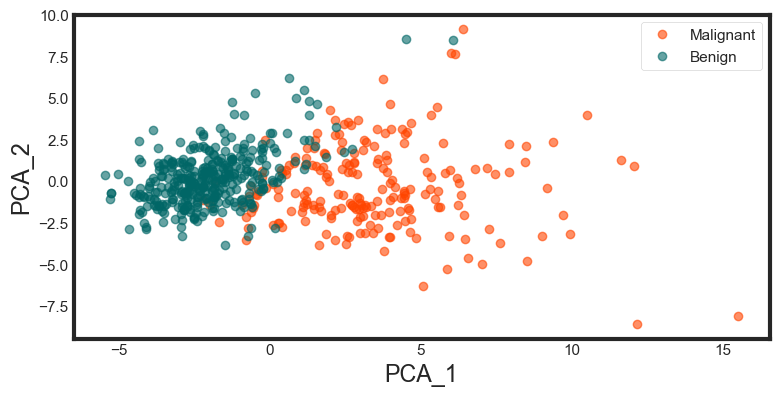

```python
# Transforming the standardzed data (Xs) using Principal Component Analysis (PCA)
X_pca = pca.transform(Xs)

# Creating a DataFrame to store the PCA results
PCA_df = pd.DataFrame()

# Assigning the first and second principal components to the DataFrame
PCA_df['PCA_1'] = X_pca[:, 0]
PCA_df['PCA_2'] = X_pca[:, 1]

# Plotting the PCA results, differentiating points based on the diagnosis ('M' or 'B')
# 'M' (Malignant) points are plotted in red, and 'B' (Benign) points are plotted in blue
plt.plot(PCA_df['PCA_1'][df.diagnosis == 'M'], PCA_df['PCA_2']
         [df.diagnosis == 'M'], 'o', alpha=0.6, color='#FF4500')
plt.plot(PCA_df['PCA_1'][df.diagnosis == 'B'], PCA_df['PCA_2']
         [df.diagnosis == 'B'], 'o', alpha=0.6, color='#006666')

# Adding labels to the axes
plt.xlabel('PCA_1')
plt.ylabel('PCA_2')

# Adding a legend to distinguish between 'Malignant' and 'Benign' points
plt.legend(['Malignant', 'Benign'])

# Displaying the plot
plt.show()
```

```python
# The amount of variance that each PC explains
var = pca.explained_variance_ratio_
# Cumulative Variance explains
var1 = np.cumsum(np.round(pca.explained_variance_ratio_, decimals=4)*100)
print(var1)
```

```
[36.92 50.75 59.72 64.52 68.97 72.82 76.35 79.67 82.89 85.87]
```

#### Determining the Optimal Number of Principal Components to Preserve

To ascertain the appropriate number of principal components to retain, a standard approach involves summarizing the outcomes of a principal components analysis through the creation of a scree plot.

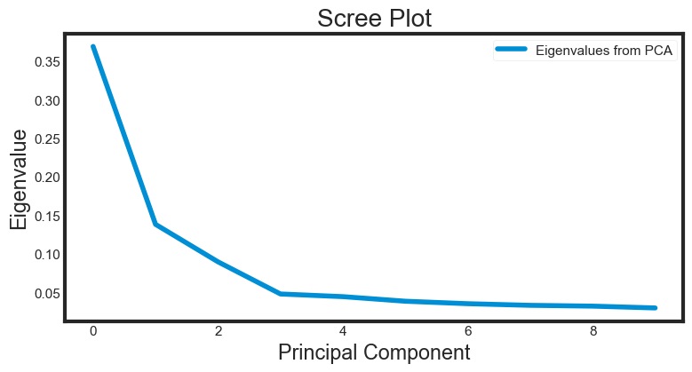

```python
# The amount of variance that each Principal Component (PC) explains
variance_explained = pca.explained_variance_ratio_

# Plotting the Scree Plot
plt.plot(variance_explained)
plt.title('Scree Plot')  # Setting the title of the plot
plt.xlabel('Principal Component')  # Labeling the x-axis
plt.ylabel('Eigenvalue')  # Labeling the y-axis

# Adding a legend to the plot
legend = plt.legend(['Eigenvalues from PCA'], loc='best',
                    borderpad=0.3, shadow=False, markerscale=0.4)

# Adjusting the transparency and draggability of the legend
legend.get_frame().set_alpha(0.4)
legend.set_draggable(state=True)

# Displaying the plot
plt.show()
```

### 4.7 K-means Clustring

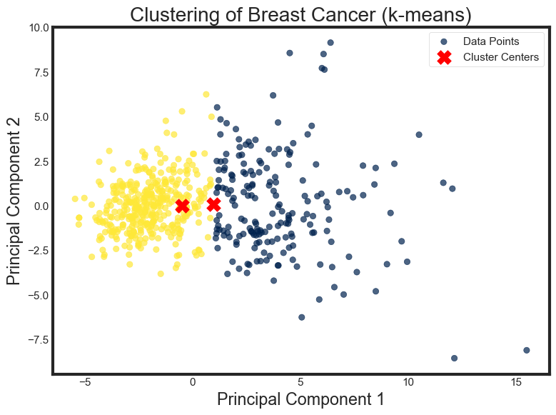

```python
from sklearn.cluster import KMeans

# Based on the elbow curve, choose the optimal number of clusters (k)
optimal_k = 2

# Apply k-means clustering
kmeans = KMeans(n_clusters=optimal_k, n_init=10, random_state=42)
clusters = kmeans.fit_predict(Xs)

# Get cluster centers
cluster_centers = kmeans.cluster_centers_

# Visualize the clusters
plt.figure(figsize=(8, 6))

# Scatter plot for data points
plt.scatter(X_pca[:, 0], X_pca[:, 1], c=clusters,
            cmap='cividis', label='Data Points', alpha=0.7)

# Scatter plot for cluster centers
plt.scatter(cluster_centers[:, 0], cluster_centers[:, 1],
            c='red', marker='X', s=200, label='Cluster Centers')

# Labels and title
plt.title('Clustering of Breast Cancer (k-means)')
plt.xlabel('Principal Component 1')
plt.ylabel('Principal Component 2')

# Add legend
plt.legend()

# Show the plot
plt.show()
```

#### Observation

> *The application of k-means clustering (k=2) revealed distinct clusters, consistent with PCA's earlier suggestion. This concise representation offers insights into inherent data patterns, paving the way for focused analysis and potential discoveries.*

### 4.8 Building a Predictive Model with Support Vector Machine (SVM)

We employ the Support Vector Machine (SVM) learning algorithm for building our predictive model. SVMs are well-known for classification tasks, proficiently managing non-linear data transformations. This capability allows the utilization of linear algorithms for model fitting, as noted in the work by Cortes and Vapnik (1995), referenced in Parmar (2020).

Kernelized SVMs exhibit robust performance on diverse datasets:

1. SVMs accommodate intricate decision boundaries, even with limited features.
2. They perform well on both low-dimensional and high-dimensional datasets, but scalability diminishes with an increasing number of samples.

   > **While effective with up to 10,000 samples, SVMs face challenges in runtime and memory usage with datasets exceeding 100,000 samples.**
3. SVMs necessitate meticulous data preprocessing and parameter tuning. Consequently, tree-based models like random forests or gradient boosting, requiring minimal preprocessing, are preferred in many scenarios.
4. SVM models present challenges in interpretability; understanding specific predictions and explaining the model to non-experts can be intricate.

### Key Parameters

Crucial parameters in kernel SVMs include:

- Regularization parameter C,
- Choice of kernel (linear, radial basis function (RBF), or polynomial),
- Kernel-specific parameters.

The relationship between gamma and C impacts the complexity of the model, where higher values lead to a more intricate model. Therefore, it is recommended to adjust C and gamma simultaneously for optimal outcomes.

```python
%matplotlib inline
import matplotlib.pyplot as plt

#Load libraries for data processing
import pandas as pd #data processing, CSV file I/O (e.g. pd.read_csv)
import numpy as np
from scipy.stats import norm

## Supervised learning.
from sklearn.preprocessing import StandardScaler
from sklearn.preprocessing import LabelEncoder
from sklearn.model_selection import train_test_split
from sklearn.svm import SVC
from sklearn.model_selection import cross_val_score
from sklearn.pipeline import make_pipeline
from sklearn.metrics import confusion_matrix
from sklearn import metrics, preprocessing
from sklearn.metrics import classification_report

# visualization
import seaborn as sns
plt.style.use('fivethirtyeight')
sns.set_style("white")

plt.rcParams['figure.figsize'] = (8,4)
#plt.rcParams['axes.titlesize'] = 'large'
```

```python
df = pd.read_csv('Data/MS4S16_Dataset_clean.csv', index_col=False)
df.drop('Unnamed: 0', axis=1, inplace=True)
np.random.seed(42)
df.head(3)
```

|  | diagnosis | radius_mean | texture_mean | perimeter_mean | area_mean | smoothness_mean | compactness_mean | concavity_mean | concave points_mean | symmetry_mean | ... | radius_worst | texture_worst | perimeter_worst | area_worst | smoothness_worst | compactness_worst | concavity_worst | concave points_worst | symmetry_worst | fractal_dimension_worst |
| --- | --- | --- | --- | --- | --- | --- | --- | --- | --- | --- | --- | --- | --- | --- | --- | --- | --- | --- | --- | --- | --- |
| 0 | M | 17.99 | 10.38 | 122.8 | 1001.0 | 0.11840 | 0.27760 | 0.3001 | 0.14710 | 0.2419 | ... | 25.38 | 17.33 | 184.6 | 2019.0 | 0.1622 | 0.6656 | 0.7119 | 0.2654 | 0.4601 | 0.11890 |
| 1 | M | 20.57 | 17.77 | 132.9 | 1326.0 | 0.08474 | 0.07864 | 0.0869 | 0.07017 | 0.1812 | ... | 24.99 | 23.41 | 158.8 | 1956.0 | 0.1238 | 0.1866 | 0.2416 | 0.1860 | 0.2750 | 0.08902 |
| 2 | M | 19.69 | 21.25 | 130.0 | 1203.0 | 0.10960 | 0.15990 | 0.1974 | 0.12790 | 0.2069 | ... | 23.57 | 25.53 | 152.5 | 1709.0 | 0.1444 | 0.4245 | 0.4504 | 0.2430 | 0.3613 | 0.08758 |

3 rows × 31 columns

```python
# Assign predictors to a variable of ndarray (matrix) type
array = df.values
X = array[:, 1:31]  # features
y = array[:, 0]

# transform the class labels from their original string representation (M and B) into integers
le = LabelEncoder()
y = le.fit_transform(y)

# Normalize the  data (center around 0 and scale to remove the variance).
scaler = StandardScaler()
Xs = scaler.fit_transform(X)
```

#### Classification with cross-validation

This process begins with a standard train/test split, followed by calculating cross-validation errors. The model with the lowest cross-validation error is selected for further evaluation.

```python
# Split records into training and testing sets.
X_train, X_test, y_train, y_test = train_test_split(
    Xs, y, test_size=0.3, random_state=2, stratify=y)

# Initialize an SVM classifier with probability estimation and train it on 70% of the dataset.
classifier = SVC(probability=True)
classifier.fit(X_train, y_train)

# Evaluate the accuracy of predictions on the remaining 30% of the test sample.
classifier_score = classifier.score(X_test, y_test)
print('\n➔ The classifier accuracy score is {:03.2f}\n'.format(
    classifier_score))
```

```
➔ The classifier accuracy score is 0.94
```

```python
# Get average of 3-fold cross-validation score using an SVC estimator.

n_folds = 3
cv_error = np.average(cross_val_score(SVC(), Xs, y, cv=n_folds))
print('\n➔ The {}-fold cross-validation accuracy score for this classifier is {:.2f}\n'.format(n_folds, cv_error))
```

```
➔ The 3-fold cross-validation accuracy score for this classifier is 0.95
```

The evaluations above used the entire set of features; now a correlation-based feature selection strategy will be employed to assess the effect of using the three features with the best correlation.

```python
from sklearn.feature_selection import SelectKBest, f_regression


# Create a pipeline combining feature selection and SVC classifier with probability estimation.
clf2 = make_pipeline(SelectKBest(f_regression, k=3), SVC(probability=True))

# Perform 3-fold cross-validation on the pipeline classifier.
scores = cross_val_score(clf2, Xs, y, cv=3)

# Calculate the average of the 3-fold cross-validation scores using an SVC estimator.
n_folds = 3
cv_error = np.average(cross_val_score(SVC(), Xs, y, cv=n_folds))
print('\n➔ The {}-fold cross-validation accuracy score for this classifier is {:.2f}\n'.format(n_folds, cv_error))
```

```
➔ The 3-fold cross-validation accuracy score for this classifier is 0.95
```

```python
# Print the scores.
print(scores)

# Calculate the average score and its uncertainty.
# - The mean score is multiplied by 100 to convert it into a percentage.
# - The standard deviation of the scores is divided by the square root of the number of samples to get the standard error of the mean.
# - The average score and its uncertainty are stored in the variable 'avg'.
avg = (100*np.mean(scores), 100*np.std(scores)/np.sqrt(scores.shape[0]))

# Print the average score and its uncertainty in a formatted string.
print("➔ The Average score and uncertainty: (%.2f +- %.3f)%%" % avg)
```

```
[0.93157895 0.97354497 0.94179894]
➔ The Average score and uncertainty: (94.90 +- 1.032)%
```

This analysis, like Parmar (2020), demonstrates that a subset of features is sufficient to design a model with equivalent performance to models that use the entire feature set. As a result, the process of feature selection emerges as a vital part of model creation, requiring meticulous consideration in all cases.

#### Model Accuracy: Receiver Operating Characteristic (ROC) curve

The ROC curve is a graphical representation of the performance of a binary classifier system as its discrimination threshold is varied. It plots two parameters: True Positive Rate (TPR) against the False Positive Rate (FPR). The area under the ROC curve, known as AUC, is a widely used measure of the performance of a classification model. A higher AUC indicates better discrimination ability in the model.

```python
from sklearn.tree import DecisionTreeClassifier

# Instantiate a decision tree classifier
clf = DecisionTreeClassifier()

# Train the classifier on the training data and make predictions on the test data
y_pred = clf.fit(X_train, y_train).predict(X_test)

# Calculate the confusion matrix to visualize the performance of the algorithm
cm = metrics.confusion_matrix(y_test, y_pred)
```

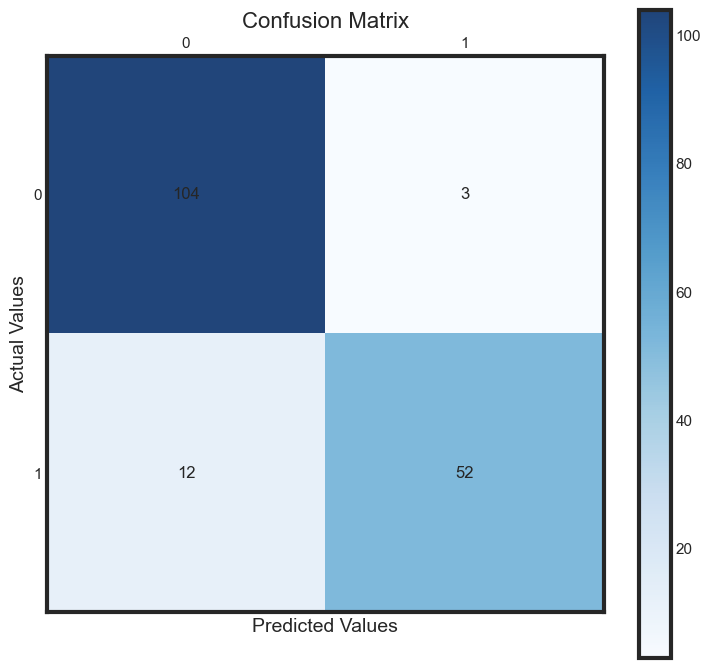

```
              precision    recall  f1-score   support

           0       0.90      0.97      0.93       107
           1       0.95      0.81      0.87        64

    accuracy                           0.91       171
   macro avg       0.92      0.89      0.90       171
weighted avg       0.91      0.91      0.91       171
```

```python
%matplotlib inline
import matplotlib.pyplot as plt


# Plot Confusion Matrix
fig, ax = plt.subplots(figsize=(8, 8))
heatmap = ax.matshow(cm, cmap=plt.cm.Blues, alpha=0.9)

# Add text annotations
for i in range(cm.shape[0]):
    for j in range(cm.shape[1]):
        ax.text(x=j, y=i, s=cm[i, j], va='center', ha='center', fontsize=12)

# Customize axis labels
plt.xlabel('Predicted Values', fontsize=14)
plt.ylabel('Actual Values', fontsize=14)

# Add color bar legend
plt.colorbar(heatmap)

# Add title
plt.title('Confusion Matrix', fontsize=16)

# Display the plot
plt.show()

# Display classification report
print(classification_report(y_test, y_pred))
```

#### Observation

There are two possible predictions: "1" and "0". Malignant = 1 (present cancer cells) and benign = 0 (absence of cancer).

> **Note:** This difference in recall rates suggests that the model is better at identifying benign cases than malignant cases. Therefore, there may be room for improvement in the model's ability to correctly identify malignant cases. This could involve refining the features used for classification, adjusting model parameters, or employing more advanced modeling techniques to better capture the characteristics of malignant cases and improve their identification.

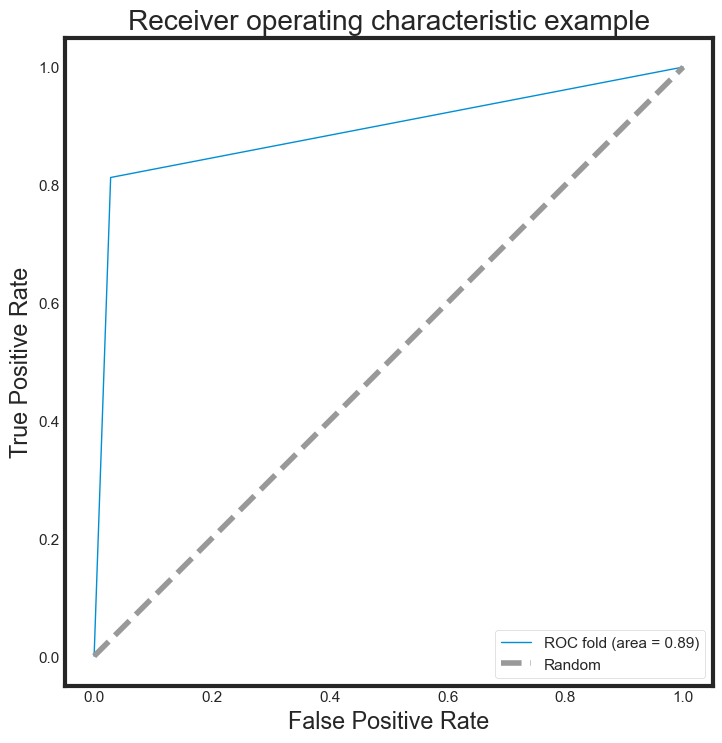

```python
from sklearn.metrics import roc_curve, auc

# Plot the receiver operating characteristic curve (ROC).
plt.figure(figsize=(10, 8))
probas_ = clf.predict_proba(X_test)
fpr, tpr, thresholds = roc_curve(y_test, probas_[:, 1])
roc_auc = auc(fpr, tpr)
plt.plot(fpr, tpr, lw=1, label='ROC fold (area = %0.2f)' % (roc_auc))
plt.plot([0, 1], [0, 1], '--', color=(0.6, 0.6, 0.6), label='Random')
plt.xlim([-0.05, 1.05])
plt.ylim([-0.05, 1.05])
plt.xlabel('False Positive Rate')
plt.ylabel('True Positive Rate')
plt.title('Receiver operating characteristic example')
plt.gca().set_aspect(1)  # Use plt.gca() instead of plt.axes()
plt.legend(loc="lower right")
plt.show()
```

#### Optimizing the SVM Classifier

Machine learning models are equipped with parameters that can be adjusted to optimize their performance for a specific task. With numerous parameters available, identifying the optimal combination can be likened to a search problem. In this section, our objective is to refine the parameters of the SVM Classification model using scikit-learn.

```python
%matplotlib inline
import matplotlib.pyplot as plt

#Load libraries for data processing
import pandas as pd #data processing, CSV file I/O (e.g. pd.read_csv)
import numpy as np
from scipy.stats import norm

## Supervised learning.
from sklearn.preprocessing import StandardScaler
from sklearn.preprocessing import LabelEncoder
from sklearn.model_selection import train_test_split
from sklearn.svm import SVC
from sklearn.model_selection import cross_val_score
from sklearn.model_selection import GridSearchCV
from sklearn.pipeline import make_pipeline
from sklearn.metrics import confusion_matrix
from sklearn import metrics, preprocessing
from sklearn.metrics import classification_report
from sklearn.feature_selection import SelectKBest, f_regression

# visualization
import seaborn as sns
plt.style.use('fivethirtyeight')
sns.set_style("white")

plt.rcParams['figure.figsize'] = (8,4)
#plt.rcParams['axes.titlesize'] = 'large'
```

#### Build a predictive model and evaluate with 5-cross validation using support vector classifies

```
The classifier accuracy score is 0.95

              precision    recall  f1-score   support

           0       0.92      1.00      0.96       107
           1       1.00      0.86      0.92        64

    accuracy                           0.95       171
   macro avg       0.96      0.93      0.94       171
weighted avg       0.95      0.95      0.95       171
```

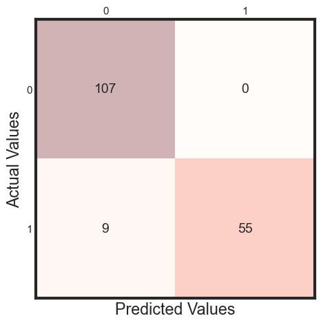

```python
from sklearn.decomposition import PCA
df = pd.read_csv('Data/MS4S16_Dataset_clean.csv', index_col=False)
df.drop('Unnamed: 0', axis=1, inplace=True)

# Assign predictors to a variable of ndarray (matrix) type
array = df.values
X = array[:, 1:31]
y = array[:, 0]

# Transform the class labels from their original string representation (M and B) into integers
le = LabelEncoder()
y = le.fit_transform(y)

# Normalize the  data (center around 0 and scale to remove the variance).
scaler = StandardScaler()
Xs = scaler.fit_transform(X)

# feature extraction
pca = PCA(n_components=10)
fit = pca.fit(Xs)
X_pca = pca.transform(Xs)

# Divide records in training and testing sets.
X_train, X_test, y_train, y_test = train_test_split(
    X_pca, y, test_size=0.3, random_state=2, stratify=y)

# Create an SVM classifier and train it on 70% of the data set.
clf = SVC(probability=True)
clf.fit(X_train, y_train)

# Analyze accuracy of predictions on 30% of the holdout test sample.
classifier_score = clf.score(X_test, y_test)
print('\nThe classifier accuracy score is {:03.2f}\n'.format(classifier_score))

clf2 = make_pipeline(SelectKBest(f_regression, k=3), SVC(probability=True))
scores = cross_val_score(clf2, X_pca, y, cv=3)

# Get average of 5-fold cross-validation score using an SVC estimator.
n_folds = 5
cv_error = np.average(cross_val_score(SVC(), X_pca, y, cv=n_folds))
# print ('\nThe {}-fold cross-validation accuracy score for this classifier is {:.2f}\n'.format(n_folds, cv_error))

y_pred = clf.fit(X_train, y_train).predict(X_test)
cm = metrics.confusion_matrix(y_test, y_pred)

print(classification_report(y_test, y_pred))

fig, ax = plt.subplots(figsize=(5, 5))
ax.matshow(cm, cmap=plt.cm.Reds, alpha=0.3)
for i in range(cm.shape[0]):
    for j in range(cm.shape[1]):
        ax.text(x=j, y=i,
                s=cm[i, j],
                va='center', ha='center')
plt.xlabel('Predicted Values', )
plt.ylabel('Actual Values')
plt.show()
```

## Significance of Classifier Optimization

Optimizing a classifier involves fine-tuning two crucial parameters within the SVM algorithm:

- The regularization parameter ( C ), which determines the trade-off between maximizing the margin and minimizing the classification error.
- The choice of kernel function, influencing the decision boundary's flexibility and the model's ability to capture complex patterns.

In Python's scikit-learn library, two primary methods facilitate algorithm parameter tuning:

- Grid Search Parameter Tuning: Exhaustively searches through a specified parameter grid to find the optimal combination.
- Random Search Parameter Tuning: Randomly samples from the parameter space, offering computational efficiency while still providing effective parameter optimization.

```python
# Train classifiers.
kernel_values = ['linear',  'poly',  'rbf',  'sigmoid']
param_grid = {
    'C': np.logspace(-3, 2, 6), 'gamma': np.logspace(-3, 2, 6), 'kernel': kernel_values}

grid = GridSearchCV(SVC(), param_grid=param_grid, cv=5)
grid.fit(X_train, y_train)
```

```
GridSearchCV(cv=5, estimator=SVC(),
             param_grid={'C': array([1.e-03, 1.e-02, 1.e-01, 1.e+00, 1.e+01, 1.e+02]),
                         'gamma': array([1.e-03, 1.e-02, 1.e-01, 1.e+00, 1.e+01, 1.e+02]),
                         'kernel': ['linear', 'poly', 'rbf', 'sigmoid']})
```

```python
print("The best parameters are %s with a score of %0.2f"
      % (grid.best_params_, grid.best_score_))
```

```
The best parameters are {'C': 10.0, 'gamma': 0.001, 'kernel': 'rbf'} with a score of 0.96
```

```python
grid.best_estimator_.probability = True
clf = grid.best_estimator_
```

```
              precision    recall  f1-score   support

           0       0.89      1.00      0.94       107
           1       1.00      0.80      0.89        64

    accuracy                           0.92       171
   macro avg       0.95      0.90      0.91       171
weighted avg       0.93      0.92      0.92       171
```

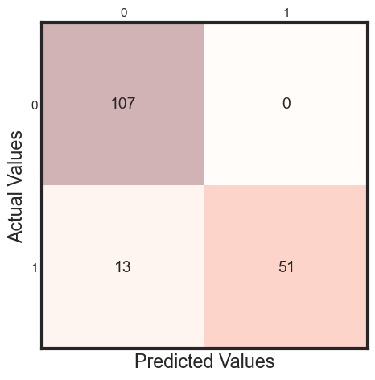

```python
y_pred = clf.fit(X_train, y_train).predict(X_test)
cm = metrics.confusion_matrix(y_test, y_pred)
# print(cm)
print(classification_report(y_test, y_pred))

fig, ax = plt.subplots(figsize=(5, 5))
ax.matshow(cm, cmap=plt.cm.Reds, alpha=0.3)
for i in range(cm.shape[0]):
    for j in range(cm.shape[1]):
        ax.text(x=j, y=i,
                s=cm[i, j],
                va='center', ha='center')
plt.xlabel('Predicted Values', )
plt.ylabel('Actual Values')
plt.show()
```

#### Decision boundaries of different classifiers

Let's see the decision boundaries produced by the linear, Gaussian and polynomial classifiers.

```python
import matplotlib.pyplot as plt
from matplotlib.colors import ListedColormap
from sklearn import svm, datasets


def decision_plot(X_train, y_train, n_neighbors, weights):
    h = .02  # step size in the mesh


Xtrain = X_train[:, :2]  # we only take the first two features.

# ================================================================
# Create color maps
# ================================================================
cmap_light = ListedColormap(['#FFAAAA', '#AAFFAA', '#AAAAFF'])
cmap_bold = ListedColormap(['#FF0000', '#00FF00', '#0000FF'])


# ================================================================
# we create an instance of SVM and fit out data.
# We do not scale ourdata since we want to plot the support vectors
# ================================================================

C = 1.0  # SVM regularization parameter

svm = SVC(kernel='linear', random_state=0, gamma=0.1, C=C).fit(Xtrain, y_train)
rbf_svc = SVC(kernel='rbf', gamma=0.7, C=C).fit(Xtrain, y_train)
poly_svc = SVC(kernel='poly', degree=3, C=C).fit(Xtrain, y_train)
```

```python
%matplotlib inline
plt.rcParams['figure.figsize'] = (15, 9)
plt.rcParams['axes.titlesize'] = 'large'

    # create a mesh to plot in
x_min, x_max = Xtrain[:, 0].min() - 1, Xtrain[:, 0].max() + 1
y_min, y_max = Xtrain[:, 1].min() - 1, Xtrain[:, 1].max() + 1
xx, yy = np.meshgrid(np.arange(x_min, x_max, 0.1),
                         np.arange(y_min, y_max, 0.1))

# title for the plots
titles = ['SVC with linear kernel',
          'SVC with RBF kernel',
          'SVC with polynomial (degree 3) kernel']
```

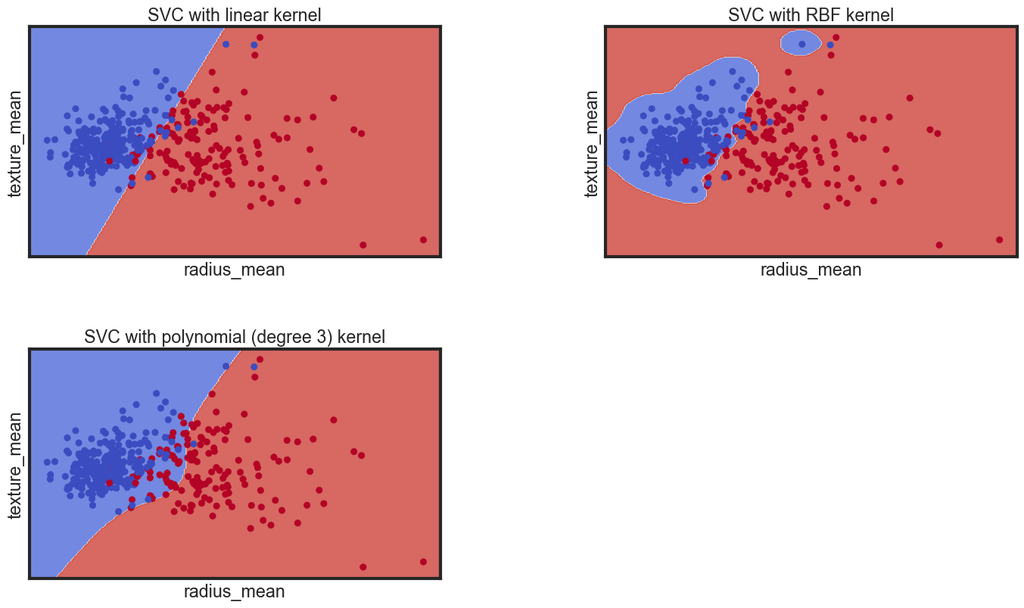

```python
for i, clf in enumerate((svm, rbf_svc, poly_svc)):
    # Plot the decision boundary. For that, we will assign a color to each
    # point in the mesh [x_min, x_max]x[y_min, y_max].
    plt.subplot(2, 2, i + 1)
    plt.subplots_adjust(wspace=0.4, hspace=0.4)

    Z = clf.predict(np.c_[xx.ravel(), yy.ravel()])

    # Put the result into a color plot
    Z = Z.reshape(xx.shape)
    plt.contourf(xx, yy, Z, cmap=plt.cm.coolwarm, alpha=0.8)

    # Plot also the training points
    plt.scatter(Xtrain[:, 0], Xtrain[:, 1], c=y_train, cmap=plt.cm.coolwarm)
    plt.xlabel('radius_mean')
    plt.ylabel('texture_mean')
    plt.xlim(xx.min(), xx.max())
    plt.ylim(yy.min(), yy.max())
    plt.xticks(())
    plt.yticks(())
    plt.title(titles[i])

plt.show()
```

#### Summary

In summary, this study showcases the classification of breast cancer utilizing Support Vector Machine (SVM) modeling techniques.

The SVM exhibits superior performance when the dataset is standardized, ensuring that all attributes possess a mean value of zero and a standard deviation of one. This standardization process can be computed from the entire training dataset and subsequently applied to standardize the input attributes of the validation dataset.

### 4.9 Evaluate Algorithms: Model Comparison

```python
%matplotlib inline
import matplotlib.pyplot as plt

import pandas as pd
import numpy as np
from scipy.stats import norm

from sklearn.model_selection import train_test_split
from sklearn.model_selection import cross_val_score
from sklearn.model_selection import KFold
from sklearn.preprocessing import LabelEncoder
from sklearn.preprocessing import StandardScaler
from sklearn.decomposition import PCA

from sklearn.pipeline import Pipeline
from sklearn.model_selection import GridSearchCV

from sklearn.linear_model import LogisticRegression
from sklearn.tree import DecisionTreeClassifier
from sklearn.discriminant_analysis import LinearDiscriminantAnalysis
from sklearn.ensemble import RandomForestClassifier
from sklearn.naive_bayes import GaussianNB
from sklearn.svm import SVC
from sklearn.metrics import confusion_matrix
from sklearn.metrics import accuracy_score
from sklearn.metrics import classification_report

# visualization
import seaborn as sns

plt.style.use('fivethirtyeight')
sns.set_style("white")

plt.rcParams['figure.figsize'] = (8,4)
```

```python
df = pd.read_csv('Data/MS4S16_Dataset_clean.csv', index_col=False)
df.drop('Unnamed: 0', axis=1, inplace=True)
np.random.seed(42)


# Split-out validation dataset
array = df.values
X = array[:, 1:31]
y = array[:, 0]

# Divide records in training and testing sets.
X_train, X_test, y_train, y_test = train_test_split(
    X, y, test_size=0.3, random_state=7)

# transform the class labels from their original string representation (M and B) into integers
le = LabelEncoder()
y = le.fit_transform(y)
```

Now it is time to create some models of the data and estimate their accuracy on unseen data.

```python
from sklearn.exceptions import ConvergenceWarning
import warnings
warnings.filterwarnings("ignore", category=ConvergenceWarning)

# Spot-Check Algorithms
models = []

# Append different classification algorithms along with their abbreviations
models.append(('LR', LogisticRegression()))  # Logistic Regression
# Linear Discriminant Analysis
models.append(('LDA', LinearDiscriminantAnalysis()))
# Classification and Regression Trees
models.append(('CART', DecisionTreeClassifier()))
models.append(('NB', GaussianNB()))  # Gaussian Naive Bayes
models.append(('SVM', SVC()))  # Support Vector Machine
models.append(('RF', RandomForestClassifier()))  # Random Forest


# Test options and evaluation metric
num_folds = 10  # Number of folds for cross-validation
num_instances = len(X_train)  # Number of instances in the training data
seed = 7  # Seed for random number generator for reproducibility
scoring = 'accuracy'  # Evaluation metric

# Initialize lists to store results
results = []  # Stores cross-validation results
names = []  # Stores names of classifiers

# Iterate over each classifier
for name, model in models:
    # Define k-fold cross-validation
    kfold = KFold(n_splits=num_folds, random_state=seed, shuffle=True)

    # Perform cross-validation and store results
    cv_results = cross_val_score(
        model, X_train, y_train, cv=kfold, scoring=scoring)
    results.append(cv_results)
    names.append(name)

    # Print mean and standard deviation of cross-validation results
    msg = "%s: %f (%f)" % (name, cv_results.mean(), cv_results.std())
    print(msg)

# Print a descriptive message indicating the completion of cross-validation
print('\n➔ 10-Fold cross-validation accuracy score for the training data for six classifiers')
```

```
LR: 0.891346 (0.046189)
LDA: 0.949359 (0.035998)
CART: 0.914231 (0.051321)
NB: 0.906538 (0.045579)
SVM: 0.899038 (0.041009)
RF: 0.954551 (0.040343)

➔ 10-Fold cross-validation accuracy score for the training data for six classifiers
```

```python
len(X_train)
```

```
397
```

#### Observation

> The findings indicate that both Random Forest and Linear Discriminant Analysis merit additional investigation. However, it's important to note that these are merely mean accuracy values. Examining the distribution of accuracy values across cross-validation folds can provide further insight. This can be visualized using box and whisker plots.

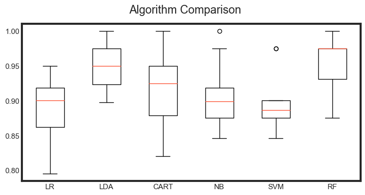

```python
# Compare Algorithms

fig = plt.figure()
fig.suptitle('Algorithm Comparison')
ax = fig.add_subplot(111)
plt.boxplot(results)
ax.set_xticklabels(names)
plt.show()
```

#### Observation

> It is most likely that the varying distribution of attributes affects the precision of algorithms like SVM. In the next section, we are going to repeat this spot-check using a standardised replica of the training dataset.

#### Analyzing Performance with Standardized Data

```python
# Standardize the dataset
pipelines = []
pipelines.append(('ScaledLR', Pipeline(
    [('Scaler', StandardScaler()), ('LR', LogisticRegression())])))
pipelines.append(('ScaledLDA', Pipeline(
    [('Scaler', StandardScaler()), ('LDA', LinearDiscriminantAnalysis())])))
pipelines.append(('ScaledRF', Pipeline(
    [('Scaler', StandardScaler()), ('RF', RandomForestClassifier())])))
pipelines.append(('ScaledCART', Pipeline(
    [('Scaler', StandardScaler()), ('CART', DecisionTreeClassifier())])))
pipelines.append(('ScaledNB', Pipeline(
    [('Scaler', StandardScaler()), ('NB', GaussianNB())])))
pipelines.append(('ScaledSVM', Pipeline(
    [('Scaler', StandardScaler()), ('SVM', SVC())])))

results = []
names = []

for name, model in pipelines:
    kfold = KFold(n_splits=num_folds, random_state=seed, shuffle=True)
    cv_results = cross_val_score(model, X_train, y_train, cv=kfold,
                                 scoring=scoring)
    results.append(cv_results)
    names.append(name)
    msg = "%s: %f (%f)" % (name, cv_results.mean(), cv_results.std())
    print(msg)
```

```
ScaledLR: 0.964679 (0.032321)
ScaledLDA: 0.949359 (0.035998)
ScaledRF: 0.959487 (0.042563)
ScaledCART: 0.924167 (0.055779)
ScaledNB: 0.909038 (0.048620)
ScaledSVM: 0.954679 (0.037098)
```

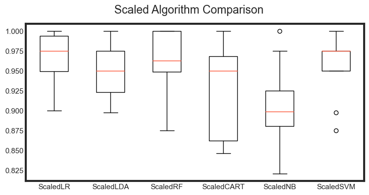

```python
# Compare Algorithms

fig = plt.figure()
fig.suptitle('Scaled Algorithm Comparison')
ax = fig.add_subplot(111)
plt.boxplot(results)
ax.set_xticklabels(names)
plt.show()
```

#### Observations

> The outcomes indicate that standardizing the data has enhanced the performance of SVM and LR algorithms significantly.

> These findings recommend further exploration of SVM, LDA, RF and LR algorithms. It is probable that tweaking the configurations beyond the default settings could lead to even more accurate models.

#### Fine-Tuning of Algorithms

let delve into the process of fine-tuning the parameters for the four promising algorithms identified during the spot-checking phase using the standardized dataset: Random Forest, Logistic Regression (LR), Linear Discriminant Analysis (LDA), and Support Vector Machine (SVM).

#### Optimization of Hyperparameters for the Support Vector Classifier

```python
# Make Support Vector Classifier Pipeline
pipe_svc = Pipeline([('scl', StandardScaler()),
                     ('pca', PCA(n_components=2)),
                     ('clf', SVC(probability=True, verbose=False))])

# Fit Pipeline to training Data
pipe_svc.fit(X_train, y_train)

# print('➝ Fitted Pipeline to training Data')

scores = cross_val_score(estimator=pipe_svc, X=X_train,
                         y=y_train, cv=10, n_jobs=1, verbose=0)
print('➔ Model Training Accuracy: %.3f +/- %.3f' %
      (np.mean(scores), np.std(scores)))

# Tune Hyperparameters
param_range = [0.0001, 0.001, 0.01, 0.1, 1.0, 10.0, 100.0, 1000.0]
param_grid = [{'clf__C': param_range, 'clf__kernel': ['linear']},
              {'clf__C': param_range, 'clf__gamma': param_range,
               'clf__kernel': ['rbf']}]
gs_svm = GridSearchCV(estimator=pipe_svc,
                      param_grid=param_grid,
                      scoring='accuracy',
                      cv=10,
                      n_jobs=1)
gs_svm = gs_svm.fit(X_train, y_train)
print('➔ Tuned Parameters Best Score: ', gs_svm.best_score_)
print('➔ Best Parameters: \n', gs_svm.best_params_)
```

```
➔ Model Training Accuracy: 0.909 +/- 0.055
➔ Tuned Parameters Best Score:  0.9241666666666667
➔ Best Parameters:
 {'clf__C': 0.1, 'clf__kernel': 'linear'}
```

#### Optimization of Hyperparameters for the LDA Classifier

```python
# Define the pipeline including LDA
pipe_lda = Pipeline([('scl', StandardScaler()),
                     ('pca', PCA(n_components=2)),
                     ('clf', LinearDiscriminantAnalysis())])

# Define the parameters grid for LDA
param_grid = {'clf__solver': ['svd', 'lsqr', 'eigen']}

# Perform cross-validation
scores = cross_val_score(estimator=pipe_lda, X=X_train,
                         y=y_train, cv=10, n_jobs=1, verbose=0)
print('➔ Model Training Accuracy: %.3f +/- %.3f' %
      (np.mean(scores), np.std(scores)))

# Perform hyperparameter tuning using GridSearchCV
gs_lda = GridSearchCV(estimator=pipe_lda,
                      param_grid=param_grid,
                      scoring='accuracy',
                      cv=10,
                      n_jobs=1)
gs_lda.fit(X_train, y_train)

# Print the results
print('➔ Tuned Parameters Best Score:', gs_lda.best_score_)
print('➔ Best Parameters:')
print(gs_lda.best_params_)
```

```
➔ Model Training Accuracy: 0.904 +/- 0.055
➔ Tuned Parameters Best Score: 0.9040384615384616
➔ Best Parameters:
{'clf__solver': 'svd'}
```

#### Optimization of Hyperparameters for the Logistic Regression

```python
# Define the pipeline including Logistic Regression
pipe_lr = Pipeline([('scl', StandardScaler()),
                    ('pca', PCA(n_components=2)),
                    ('clf', LogisticRegression())])

# Define the parameters grid for Logistic Regression
param_grid = {'clf__C': [0.001, 0.01, 0.1, 1, 10, 100, 1000],
              'clf__solver': ['newton-cg', 'lbfgs', 'liblinear', 'sag', 'saga']}

# Perform cross-validation
scores = cross_val_score(estimator=pipe_lr, X=X_train,
                         y=y_train, cv=10, n_jobs=1, verbose=0)
print('➔ Model Training Accuracy: %.3f +/- %.3f' %
      (np.mean(scores), np.std(scores)))

# Perform hyperparameter tuning using GridSearchCV
gs_lgr = GridSearchCV(estimator=pipe_lr,
                      param_grid=param_grid,
                      scoring='accuracy',
                      cv=10,
                      n_jobs=1)
gs_lgr.fit(X_train, y_train)

# Print the results
print('➔ Tuned Parameters Best Score:', gs_lgr.best_score_)
print('➔ Best Parameters:')
print(gs_lgr.best_params_)
```

```
➔ Model Training Accuracy: 0.914 +/- 0.064
➔ Tuned Parameters Best Score: 0.9217307692307692
➔ Best Parameters:
{'clf__C': 0.01, 'clf__solver': 'liblinear'}
```

#### Optimization of Hyperparameters for Random Forest

```python
# Make Random Forest Classifier Pipeline
pipe_rf = Pipeline([('scl', StandardScaler()),
                    ('pca', PCA(n_components=2)),
                    ('clf', RandomForestClassifier())])

# Fit Pipeline to training Data
pipe_rf.fit(X_train, y_train)

# print('➝ Fitted Pipeline to training Data')

scores = cross_val_score(estimator=pipe_rf, X=X_train,
                         y=y_train, cv=10, n_jobs=1, verbose=0)
print('➔ Model Training Accuracy: %.3f +/- %.3f' %
      (np.mean(scores), np.std(scores)))

# Tune Hyperparameters
param_grid = {'clf__n_estimators': [10, 50, 100, 200],
              'clf__max_depth': [None, 10, 20, 30],
              'clf__min_samples_split': [2, 5, 10],
              'clf__min_samples_leaf': [1, 2, 4]}

gs_rf = GridSearchCV(estimator=pipe_rf,
                     param_grid=param_grid,
                     scoring='accuracy',
                     cv=10,
                     n_jobs=1)
gs_rf = gs_rf.fit(X_train, y_train)
print('➔ Tuned Parameters Best Score: ', gs_rf.best_score_)
print('➔ Best Parameters: \n', gs_rf.best_params_)
```

```
➔ Model Training Accuracy: 0.904 +/- 0.042
➔ Tuned Parameters Best Score:  0.9167948717948718
➔ Best Parameters:
 {'clf__max_depth': 30, 'clf__min_samples_leaf': 2, 'clf__min_samples_split': 2, 'clf__n_estimators': 10}
```

### Finalizing the Models: SVM, LDA, Logistic Regression and Random Forest

SVM

```python
# Use best parameters
# Retrieve the best estimator found during grid search
clf_svc = gs_svm.best_estimator_

# Get Final Scores
# Train the best estimator on the entire training dataset
clf_svc.fit(X_train, y_train)

# Perform cross-validation to evaluate the model's performance
# Compute accuracy scores using cross-validation with 10 folds
scores = cross_val_score(estimator=clf_svc,
                         X=X_train,
                         y=y_train,
                         cv=10,
                         n_jobs=1)

# Print the final model training accuracy
# Calculate and print the mean and standard deviation of the accuracy scores
print('➔ Final Model Training Accuracy: %.3f +/- %.3f' %
      (np.mean(scores), np.std(scores)))

# Evaluate the model's performance on the test set
# Calculate and print the accuracy of the model on the test set
print('➜ Final Accuracy on Test set: %.5f' % clf_svc.score(X_test, y_test))
```

```
➔ Final Model Training Accuracy: 0.924 +/- 0.062
➜ Final Accuracy on Test set: 0.95906
```

```python
# Train the Support Vector Classifier (SVC) model using the training data (X_train, y_train)
clf_svc.fit(X_train, y_train)

# Use the trained SVC model to make predictions on the test data (X_test)
y_pred = clf_svc.predict(X_test)

# Print the accuracy score of the model by comparing the predicted labels (y_pred) with the true labels (y_test)
print(accuracy_score(y_test, y_pred))

# Print the confusion matrix, which shows the number of true positives, true negatives, false positives, and false negatives
# for each class (in this case, for binary classification)
print(confusion_matrix(y_test, y_pred))

# Print the classification report, which includes precision, recall, F1-score, and support for each class,
# as well as the overall metrics averaged across all classes
print(classification_report(y_test, y_pred))
```

```
0.9590643274853801
[[113   3]
 [  4  51]]
              precision    recall  f1-score   support

           B       0.97      0.97      0.97       116
           M       0.94      0.93      0.94        55

    accuracy                           0.96       171
   macro avg       0.96      0.95      0.95       171
weighted avg       0.96      0.96      0.96       171
```

Logistic Regression

```python
# Use best parameters
# Retrieve the best estimator found during grid search
clf_log_reg = gs_lgr.best_estimator_

# Get Final Scores
# Train the best estimator on the entire training dataset
clf_log_reg.fit(X_train, y_train)

# Perform cross-validation to evaluate the model's performance
# Compute accuracy scores using cross-validation with 10 folds
scores = cross_val_score(estimator=clf_log_reg,
                         X=X_train,
                         y=y_train,
                         cv=10,
                         n_jobs=1)

# Print the final model training accuracy
# Calculate and print the mean and standard deviation of the accuracy scores
print('➔ Final Model Training Accuracy: %.3f +/- %.3f' %
      (np.mean(scores), np.std(scores)))

# Evaluate the model's performance on the test set
# Calculate and print the accuracy of the model on the test set
print('➜ Final Accuracy on Test set: %.5f' % clf_log_reg.score(X_test, y_test))
```

```
➔ Final Model Training Accuracy: 0.922 +/- 0.057
➜ Final Accuracy on Test set: 0.95322
```

```python
# Train the Support Vector Classifier (SVC) model using the training data (X_train, y_train)
clf_log_reg.fit(X_train, y_train)

# Use the trained SVC model to make predictions on the test data (X_test)
y_pred = clf_log_reg.predict(X_test)

# Print the accuracy score of the model by comparing the predicted labels (y_pred) with the true labels (y_test)
print(accuracy_score(y_test, y_pred))

# Print the confusion matrix, which shows the number of true positives, true negatives, false positives, and false negatives
# for each class (in this case, for binary classification)
print(confusion_matrix(y_test, y_pred))

# Print the classification report, which includes precision, recall, F1-score, and support for each class,
# as well as the overall metrics averaged across all classes
print(classification_report(y_test, y_pred))
```

```
0.9532163742690059
[[112   4]
 [  4  51]]
              precision    recall  f1-score   support

           B       0.97      0.97      0.97       116
           M       0.93      0.93      0.93        55

    accuracy                           0.95       171
   macro avg       0.95      0.95      0.95       171
weighted avg       0.95      0.95      0.95       171
```

LDA

```python
# Use best parameters
# Retrieve the best estimator found during grid search
clf_lda = gs_lda.best_estimator_

# Get Final Scores
# Train the best estimator on the entire training dataset
clf_lda.fit(X_train, y_train)

# Perform cross-validation to evaluate the model's performance
# Compute accuracy scores using cross-validation with 10 folds
scores = cross_val_score(estimator=clf_lda,
                         X=X_train,
                         y=y_train,
                         cv=10,
                         n_jobs=1)

# Print the final model training accuracy
# Calculate and print the mean and standard deviation of the accuracy scores
print('➔ Final Model Training Accuracy: %.3f +/- %.3f' %
      (np.mean(scores), np.std(scores)))

# Evaluate the model's performance on the test set
# Calculate and print the accuracy of the model on the test set
print('➜ Final Accuracy on Test set: %.5f' % clf_lda.score(X_test, y_test))
```

```
➔ Final Model Training Accuracy: 0.904 +/- 0.055
➜ Final Accuracy on Test set: 0.95322
```

```python
# Train the Support Vector Classifier (SVC) model using the training data (X_train, y_train)
clf_lda.fit(X_train, y_train)

# Use the trained SVC model to make predictions on the test data (X_test)
y_pred = clf_lda.predict(X_test)

# Print the accuracy score of the model by comparing the predicted labels (y_pred) with the true labels (y_test)
print(accuracy_score(y_test, y_pred))

# Print the confusion matrix, which shows the number of true positives, true negatives, false positives, and false negatives
# for each class (in this case, for binary classification)
print(confusion_matrix(y_test, y_pred))

# Print the classification report, which includes precision, recall, F1-score, and support for each class,
# as well as the overall metrics averaged across all classes
print(classification_report(y_test, y_pred))
```

```
0.9532163742690059
[[116   0]
 [  8  47]]
              precision    recall  f1-score   support

           B       0.94      1.00      0.97       116
           M       1.00      0.85      0.92        55

    accuracy                           0.95       171
   macro avg       0.97      0.93      0.94       171
weighted avg       0.96      0.95      0.95       171
```

Random Forest

```python
# Use best parameters
# Retrieve the best estimator found during grid search
clf_rf = gs_rf.best_estimator_

# Get Final Scores
# Train the best estimator on the entire training dataset
clf_rf.fit(X_train, y_train)

# Perform cross-validation to evaluate the model's performance
# Compute accuracy scores using cross-validation with 10 folds
scores = cross_val_score(estimator=clf_rf,
                         X=X_train,
                         y=y_train,
                         cv=10,
                         n_jobs=1)

# Print the final model training accuracy
# Calculate and print the mean and standard deviation of the accuracy scores
print('➔ Final Model Training Accuracy: %.3f +/- %.3f' %
      (np.mean(scores), np.std(scores)))

# Evaluate the model's performance on the test set
# Calculate and print the accuracy of the model on the test set
print('➜ Final Accuracy on Test set: %.5f' % clf_rf.score(X_test, y_test))
```

```
➔ Final Model Training Accuracy: 0.914 +/- 0.044
➜ Final Accuracy on Test set: 0.96491
```

```python
# Train the Support Vector Classifier (SVC) model using the training data (X_train, y_train)
clf_rf.fit(X_train, y_train)

# Use the trained SVC model to make predictions on the test data (X_test)
y_pred = clf_rf.predict(X_test)

# Print the accuracy score of the model by comparing the predicted labels (y_pred) with the true labels (y_test)
print(accuracy_score(y_test, y_pred))

# Print the confusion matrix, which shows the number of true positives, true negatives, false positives, and false negatives
# for each class (in this case, for binary classification)
print(confusion_matrix(y_test, y_pred))

# Print the classification report, which includes precision, recall, F1-score, and support for each class,
# as well as the overall metrics averaged across all classes
print(classification_report(y_test, y_pred))
```

```
0.9590643274853801
[[113   3]
 [  4  51]]
              precision    recall  f1-score   support

           B       0.97      0.97      0.97       116
           M       0.94      0.93      0.94        55

    accuracy                           0.96       171
   macro avg       0.96      0.95      0.95       171
weighted avg       0.96      0.96      0.96       171
```

#### Summary

The parameter optimization results for various machine learning algorithms on the test dataset are as follows:

Support Vector Machine (SVM) achieved an accuracy of 95.91%. The confusion matrix indicates that it correctly classified 113 instances of class B and 51 instances of class M, with only 3 false positives and 4 false negatives. The precision, recall, and F1-score for both classes are high, indicating robust performance.

Logistic Regression attained an accuracy of 95.32%. It correctly classified 112 instances of class B and 51 instances of class M, with 4 false positives and 4 false negatives. Similar to SVM, the precision, recall, and F1-score for both classes are commendable.

Linear Discriminant Analysis (LDA) also achieved an accuracy of 95.32%. It correctly classified 116 instances of class B and 47 instances of class M, with no false positives but 8 false negatives. While the precision for class M is perfect, the recall is slightly lower, leading to a lower F1-score for class M compared to class B.

In conclusion, after parameter optimization, all algorithms demonstrated high accuracy and generally performed well in classifying instances of class B and class M. Random Forest slightly outperformed the other algorithms in terms of accuracy, but all models achieved satisfactory results.

## 5: Conclusion

The study explores the application of machine learning algorithms, particularly Support Vector Machines (SVM), in predicting breast cancer outcomes. It emphasizes the importance of accurate prediction for early detection, tailored treatment plans, and improved patient outcomes. The study incorporates dimensionality reduction and clustering techniques to enhance model performance and interpretability. It compares SVM with other algorithms like random forests, Linear Discriminant Analysis (LDA), and logistic regression to determine the most effective predictive model. The findings have significant implications for clinical practice, including improved diagnostic accuracy, tailored treatment plans, and early detection. Future research directions include integrating biomarker data, longitudinal data analysis, external validation, and clinical implementation of predictive models. These efforts aim to advance breast cancer prediction and contribute to better patient outcomes and quality of care.

## 6: References

Cancer Research UK (2023) Breast Biopsy. Available at: https://www.cancerresearchuk.org/about-cancer/tests-and-scans/breast-biopsy (Accessed: 4 January 2024).

Cortes, C. and Vapnik, V. (1995) ‘Support-vector networks’. *Machine Learning* 20(3), pp. 273–297. Available at: https://link.springer.com/article/10.1007/bf00994018 (Accessed: 5 January 2024).

Cox, C.S. et al. (1998) ‘Guidelines for Sentinel Node Biopsy and Lymphatic Mapping of Patients with Breast Cancer’. *Guidelines for Sentinel Node Biopsy and Lymphatic Mapping of Patients with Breast Cancer* 227(5), pp. 645–653. doi: https://doi.org/10.1097/00000658-199805000-00005.

Géron, A. (2019) *Hands-on Machine Learning with Scikit-Learn and TensorFlow concepts, tools, and Techniques to Build Intelligent Systems*. 2nd edn. O’Reilly Media, Inc., pp. 222–225.

Mu, T. and Nandi, A.K. (2007) ‘Breast Cancer Detection from FNA Using SVM with Different Parameter Tuning Systems and SOM–RBF Classifier’. *Journal of the Franklin Institute* 344(3-4), pp. 285–311. doi: https://doi.org/10.1016/j.jfranklin.2006.09.005.

OpenAI (2024) ChatGPT. Available at: https://chat.openai.com (Accessed: 5 February 2024).

Parmar, M. (2020) 93_Python_Data_Analytics_Projects. Available at: https://github.com/milaan9/93_Python_Data_Analytics_Projects/blob/main/007_Breast_Cancer_Prediction_with_ML/Breast_Cancer_Prediction.ipynb (Accessed: 2 February 2024).

Programmer7129 (2022) Breast-Cancer-Prediction-Machine-Learning-Model. Available at: https://github.com/Programmer7129/Breast-Cancer-Prediction-Machine-Learning-Model/blob/main/Breast%20Cancer%20Prediction%20Model.ipynb (Accessed: 5 February 2024).

Siegel, R.L., Miller, K.D. and Jemal, A. (2020) ‘Cancer statistics, 2020’. *CA: a Cancer Journal for Clinicians* 70(1), pp. 7–30. doi: https://doi.org/10.3322/caac.21590.